# Taller 2: Mercado Laboral y Micronegocios en Colombia

Cuaderno Analítico, Reproducible y Pedagógico (GEIH y EMICRON 2023-2024)

Autor/a

Afiliación

Grupo 10: Juan José Echeverry, Miguelangel Palma, Sergio López

Maestría en Economía Aplicada (MECA) · Universidad de los Andes

Fecha de publicación

10 de octubre de 2026

# 1 Introducción y Filosofía Pedagógica

Este cuaderno presenta la solución integral del **Taller 2 de Programación en R** estructurada bajo los principios de la *Guía pedagógica para escribir código y documentación en R*.

Siguiendo dicha guía, el documento opera como una **explicación ejecutable** organizada en tres capas complementarias:

1. **Antes del código (Markdown):** Se explicita la pregunta analítica, los insumos requeridos, la regla metodológica aplicada y el objeto esperado.
2. **Dentro del código (R):** Se emplean nombres mnemónicos en `snake_case`, etiquetas únicas para cada chunk, verificación de condiciones de parada (`stop()`) y comentarios breves sobre decisiones locales y denominadores.
3. **Después del código (Interpretación):** Se ofrece una lectura sustantiva de la evidencia obtenida (magnitudes, comparaciones y patrones visuales), distinguiendo análisis descriptivo/asociativo de causalidad y reconociendo explícitamente los límites de los datos.

# 2 Configuración Inicial y Parámetros Globales

### 2.0.1 Propósito y dependencias del entorno

Este bloque inicial declara todas las dependencias del proyecto, garantizando que el análisis se ejecute sin paquetes no autorizados. Asimismo, centraliza la construcción de rutas relativas con `{here}`, evitando rutas absolutas dependientes de la máquina local.

**Código R**

```r
# 0.1 Limpieza defensiva del entorno
rm(list = ls())

# 0.2 Carga de librerías autorizadas en el curso
suppressPackageStartupMessages(library(here)) # Resolución reproducible de rutas relativas a la raíz del proyecto
library(dplyr)      # Gramática de manipulación de datos y agregaciones
```

**Código R**

```r
library(tidyr)      # Reestructuración de tablas y formatos anchos/largos
library(ggplot2)    # Visualización gramatical de datos
library(openxlsx)   # Exportación tabular a hojas de cálculo Excel
library(knitr)      # Formato elegante de tablas ejecutables en Quarto

# 0.3 Definición centralizada de rutas base
ruta_raiz    <- here::here()
ruta_datos   <- file.path(ruta_raiz, "Datos")
ruta_emicron <- file.path(ruta_datos, "EMICRON_2024")
ruta_outputs <- file.path(ruta_raiz, "outputs")

# Garantizar existencia del directorio de salidas
if (!dir.exists(ruta_outputs)) {
  dir.create(ruta_outputs, recursive = TRUE)
}
```

La configuración inicial garantiza que cualquier persona u evaluador pueda reproducir este análisis de principio a fin simplemente clonando el repositorio y ejecutando el documento desde una sesión limpia.

# 3 Punto 1: Conformación y Unión de las Bases de Datos

## 3.1 1.1 Pegue de las bases de datos de la GEIH (2023 y 2024)

### 3.1.1 Planteamiento y estrategia de eficiencia

El objetivo es construir la base consolidada de la Gran Encuesta Integrada de Hogares (GEIH) para los 24 meses comprendidos entre enero de 2023 y diciembre de 2024. Cada mes se compone de cuatro módulos independientes: 1. *Características generales, seguridad social en salud y educación* (módulo base universal de personas). 2. *Fuerza de trabajo* (población en edad de trabajar, PET). 3. *Ocupados* (población ocupada, OCI). 4. *No ocupados* (población desocupada e inactiva).

**Llave de persona:** En la GEIH, la persona queda unívocamente identificada por la tupla:
$$\text{Llave} = (\text{DIRECTORIO}, \text{SECUENCIA\_P}, \text{ORDEN})$$
donde `DIRECTORIO` identifica la vivienda, `SECUENCIA_P` el hogar dentro de la vivienda, y `ORDEN` la persona dentro del hogar.

**Estrategia de eficiencia:** Para evitar saturar la memoria RAM con cientos de variables no solicitadas de los módulos de ocupados, la selección de columnas (`select`) se realiza **inmediatamente después de la lectura de cada archivo CSV**. Además, se audita en cada iteración que ningún pegue por la izquierda (`left_join`) multiplique las filas del módulo base.

**Código R**

```r
# Definición de períodos y llave maestra
anios <- c("GEIH_2023", "GEIH_2024")
meses <- c(
  "01_Enero", "02_Febrero", "03_Marzo", "04_Abril",
  "05_Mayo", "06_Junio", "07_Julio", "08_Agosto",
  "09_Septiembre", "10_Octubre", "11_Noviembre", "12_Diciembre"
)
llave_geih <- c("DIRECTORIO", "SECUENCIA_P", "ORDEN")

# Contenedores para almacenar bases consolidadas y matrices de auditoría
bases_anuales           <- list()
conteos_modulos         <- list()
verificacion_llaves     <- list()
verificacion_pegues     <- list()
verificacion_eficiencia <- list()

# Contador global para indexar las listas de auditoría y verificación mensual.
# Se inicializa en 1 antes de los bucles y se incrementa en 1 en cada iteración mensual
# (corriendo de 1 a 24 para los 24 meses analizados en 2023 y 2024).
# El contador asigna una posición a cada mes en las listas de auditoría.
# Las listas se inicializan vacías y se consolidan al final con bind_rows();
# esta indexación no constituye una preasignación de memoria.
contador <- 1

# Bucle anidado: 2 años x 12 meses = 24 iteraciones
for (anio in anios) {
  bases_mensuales_anio <- list()

  for (i in 1:12) {
    mes <- meses[i]
    ruta_mes <- file.path(ruta_datos, anio, mes)

    # Manejo de excepción contractual en GEIH_2024 Marzo
    archivo_no_ocupados <- if (anio == "GEIH_2024" && mes == "03_Marzo") "No ocupado.CSV" else "No ocupados.CSV"

    # 1.1.3.1 Lectura de módulos mensuales
    general     <- read.csv(file.path(ruta_mes, "Características generales, seguridad social en salud y educación.CSV"), sep = ";")
    fuerza      <- read.csv(file.path(ruta_mes, "Fuerza de trabajo.CSV"), sep = ";")
    ocupados    <- read.csv(file.path(ruta_mes, "Ocupados.CSV"), sep = ";")
    no_ocupados <- read.csv(file.path(ruta_mes, archivo_no_ocupados), sep = ";")

    # 1.1.3.2 Auditoría de tamaño muestral por módulo
    conteos_modulos[[contador]] <- data.frame(
      ANIO          = anio,
      MES           = mes,
      GENERAL       = nrow(general),
      FUERZA_MODULO = nrow(fuerza),
      OCUPADOS      = nrow(ocupados),
      NO_OCUPADOS   = nrow(no_ocupados)
    )

    # 1.1.3.3 Registro de columnas previas para auditoría de eficiencia
    col_gen_ant     <- ncol(general)
    col_fuer_ant    <- ncol(fuerza)
    col_ocup_ant    <- ncol(ocupados)
    col_no_ocup_ant <- ncol(no_ocupados)

    # 1.1.3.4 Selección estricta de variables de interés
    general <- general %>%
      select(
        DIRECTORIO, SECUENCIA_P, ORDEN, PERIODO, MES,
        P3271, P3042, P6090, P6040, P6160, DPTO, AREA, CLASE, FEX_C18, PT,
        P6100, P6110
      )

    fuerza <- fuerza %>%
      select(DIRECTORIO, SECUENCIA_P, ORDEN, PET, FT, FFT, P6240)

    ocupados <- ocupados %>%
      select(
        DIRECTORIO, SECUENCIA_P, ORDEN, OCI, RAMA2D_R4, P6430, INGLABO,
        P3045S1, P3046, P3069, P6765, P3065, P3066, OFICIO_C8,
        P3067, P3067S1, P3067S2, P6775, P3068, P6450, P6920, P6930, P6940
      )

    no_ocupados <- no_ocupados %>%
      select(DIRECTORIO, SECUENCIA_P, ORDEN, DSI)

    # 1.1.3.5 Registro de reducción de dimensionalidad
    verificacion_eficiencia[[contador]] <- data.frame(
      ANIO                = anio,
      MES                 = mes,
      GENERAL_ANTES       = col_gen_ant,
      GENERAL_DESPUES     = ncol(general),
      FUERZA_ANTES        = col_fuer_ant,
      FUERZA_DESPUES      = ncol(fuerza),
      OCUPADOS_ANTES      = col_ocup_ant,
      OCUPADOS_DESPUES    = ncol(ocupados),
      NO_OCUPADOS_ANTES   = col_no_ocup_ant,
      NO_OCUPADOS_DESPUES = ncol(no_ocupados)
    )

    # 1.1.3.6 Homogeneización de tipos de datos en la llave
    general$DIRECTORIO <- as.character(general$DIRECTORIO)
    general$SECUENCIA_P <- as.character(general$SECUENCIA_P)
    general$ORDEN <- as.character(general$ORDEN)

    fuerza$DIRECTORIO <- as.character(fuerza$DIRECTORIO)
    fuerza$SECUENCIA_P <- as.character(fuerza$SECUENCIA_P)
    fuerza$ORDEN <- as.character(fuerza$ORDEN)

    ocupados$DIRECTORIO <- as.character(ocupados$DIRECTORIO)
    ocupados$SECUENCIA_P <- as.character(ocupados$SECUENCIA_P)
    ocupados$ORDEN <- as.character(ocupados$ORDEN)

    no_ocupados$DIRECTORIO <- as.character(no_ocupados$DIRECTORIO)
    no_ocupados$SECUENCIA_P <- as.character(no_ocupados$SECUENCIA_P)
    no_ocupados$ORDEN <- as.character(no_ocupados$ORDEN)

    # 1.1.3.7 Verificación crítica: unicidad de la llave en cada módulo
    dup_gen     <- sum(duplicated(general[, llave_geih]))
    dup_fuer    <- sum(duplicated(fuerza[, llave_geih]))
    dup_ocup    <- sum(duplicated(ocupados[, llave_geih]))
    dup_no_ocup <- sum(duplicated(no_ocupados[, llave_geih]))

    verificacion_llaves[[contador]] <- data.frame(
      ANIO = anio, MES = mes,
      DUP_GENERAL = dup_gen, DUP_FUERZA = dup_fuer,
      DUP_OCUPADOS = dup_ocup, DUP_NO_OCUPADOS = dup_no_ocup
    )

    if (dup_gen > 0 || dup_fuer > 0 || dup_ocup > 0 || dup_no_ocup > 0) {
      stop(paste("ERROR CRÍTICO: Llaves duplicadas detectadas en", anio, mes))
    }

    # 1.1.3.8 y 1.1.3.9 Pegue secuencial y verificación de no multiplicación
    n_gen <- nrow(general)

    base_mes <- general %>%
      left_join(fuerza, by = llave_geih)
    filas_fuerza <- nrow(base_mes)

    base_mes <- base_mes %>%
      left_join(ocupados, by = llave_geih)
    filas_ocupados <- nrow(base_mes)

    base_mes <- base_mes %>%
      left_join(no_ocupados, by = llave_geih)
    filas_no_ocupados <- nrow(base_mes)

    verificacion_pegues[[contador]] <- data.frame(
      ANIO                = anio,
      MES                 = mes,
      GENERAL             = n_gen,
      DESPUES_FUERZA      = filas_fuerza,
      DESPUES_OCUPADOS    = filas_ocupados,
      DESPUES_NO_OCUPADOS = filas_no_ocupados
    )

    if (filas_fuerza != n_gen || filas_ocupados != n_gen || filas_no_ocupados != n_gen) {
      stop(paste("ERROR CRÍTICO: Multiplicación de filas en", anio, mes))
    }

    # 1.1.3.10 Extracción de variable ANIO y almacenamiento mensual
    base_mes <- base_mes %>%
      mutate(ANIO = as.numeric(substr(as.character(PERIODO), 1, 4)))

    # Almacenar la base del mes i (1 a 12) en la lista acumuladora del año actual
    bases_mensuales_anio[[i]] <- base_mes

    # Registro en consola del progreso mensual procesado
    cat("Procesado:", anio, "-", mes, "\n")

    # Incrementar el contador global de auditoría mensual (1 a 24)
    contador <- contador + 1
  }

  ### 1.1.4) Construir las bases anuales ----
  # Consolida los 12 meses del año en un único data frame anual mediante bind_rows
  bases_anuales[[anio]] <- bind_rows(bases_mensuales_anio)
}
```

```
Procesado: GEIH_2023 - 01_Enero
Procesado: GEIH_2023 - 02_Febrero
Procesado: GEIH_2023 - 03_Marzo
Procesado: GEIH_2023 - 04_Abril
Procesado: GEIH_2023 - 05_Mayo
Procesado: GEIH_2023 - 06_Junio
Procesado: GEIH_2023 - 07_Julio
Procesado: GEIH_2023 - 08_Agosto
Procesado: GEIH_2023 - 09_Septiembre
Procesado: GEIH_2023 - 10_Octubre
Procesado: GEIH_2023 - 11_Noviembre
Procesado: GEIH_2023 - 12_Diciembre
Procesado: GEIH_2024 - 01_Enero
Procesado: GEIH_2024 - 02_Febrero
Procesado: GEIH_2024 - 03_Marzo
Procesado: GEIH_2024 - 04_Abril
Procesado: GEIH_2024 - 05_Mayo
Procesado: GEIH_2024 - 06_Junio
Procesado: GEIH_2024 - 07_Julio
Procesado: GEIH_2024 - 08_Agosto
Procesado: GEIH_2024 - 09_Septiembre
Procesado: GEIH_2024 - 10_Octubre
Procesado: GEIH_2024 - 11_Noviembre
Procesado: GEIH_2024 - 12_Diciembre
```

**Código R**

```r
# 1.1.5 Consolidación maestro GEIH (2023 - 2024)
GEIH_2023 <- bases_anuales[["GEIH_2023"]]
GEIH_2024 <- bases_anuales[["GEIH_2024"]]
GEIH      <- bind_rows(GEIH_2023, GEIH_2024)

# Consolidación de tablas de verificación
tabla_llaves     <- bind_rows(verificacion_llaves)
tabla_pegues     <- bind_rows(verificacion_pegues)
tabla_eficiencia <- bind_rows(verificacion_eficiencia)

# Exportación de artefactos de verificación
write.csv(tabla_llaves, file.path(ruta_outputs, "1_1_verificacion_llaves.csv"), row.names = FALSE)
write.csv(tabla_pegues, file.path(ruta_outputs, "1_1_verificacion_pegues.csv"), row.names = FALSE)
write.csv(tabla_eficiencia, file.path(ruta_outputs, "1_1_eficiencia.csv"), row.names = FALSE)
```

### 3.1.2 Interpretación y auditoría de la consolidación

La tabla siguiente resume una muestra de las validaciones de pegue y unicidad de llaves:

Auditoría de integridad muestral: Coincidencia exacta de filas antes y después del pegue

| ANIO | MES | GENERAL | DESPUES_FUERZA | DESPUES_OCUPADOS | DESPUES_NO_OCUPADOS |
| --- | --- | --- | --- | --- | --- |
| GEIH_2023 | 01_Enero | 73471 | 73471 | 73471 | 73471 |
| GEIH_2023 | 02_Febrero | 74214 | 74214 | 74214 | 74214 |
| GEIH_2023 | 03_Marzo | 73415 | 73415 | 73415 | 73415 |
| GEIH_2023 | 04_Abril | 72222 | 72222 | 72222 | 72222 |

**Evidencia de integridad:** - En los 24 meses analizados, la suma de duplicados en la llave `(DIRECTORIO, SECUENCIA_P, ORDEN)` fue exactamente **cero** para los 4 módulos. - El número de filas tras el pegue secuencial de Fuerza de Trabajo, Ocupados y No Ocupados se mantuvo exactamente igual a las filas del módulo base de Características Generales (`GENERAL == DESPUES_FUERZA == DESPUES_OCUPADOS == DESPUES_NO_OCUPADOS`). - La selección de variables redujo Ocupados de 200 a 23 columnas (88,5 %). Este control mide el ancho de la tabla; no mide directamente el ahorro de RAM.

## 3.2 1.2 Descripción General de los Datos de la GEIH 2024

### 3.2.1 Propósito y relaciones esperadas entre módulos

Se realiza la caracterización del tamaño muestral mensual para 2024 y se contrastan las identidades conceptuales del mercado laboral según las definiciones del DANE: 1. $\text{General} \ge \text{Fuerza de trabajo (PET)}$, dado que la PET comprende a las personas de 15 años y más. 2. $\text{Fuerza de trabajo (PET)} = \text{Ocupados} + \text{No ocupados}$, partición exhaustiva de la PET. 3. $\text{PET} = \text{FT (Fuerza de Trabajo)} + \text{FFT (Fuera de la Fuerza de Trabajo)}$. 4. $\text{FT} = \text{Ocupados (OCI)} + \text{Desocupados (DSI)}$.

**Código R**

```r
# 1.2.1 y 1.2.2 Filtrar 2024 y evaluar relaciones
tabla_modulos_2024 <- bind_rows(conteos_modulos) %>%
  filter(ANIO == "GEIH_2024") %>%
  mutate(
    GENERAL_MAYOR_PET = GENERAL >= FUERZA_MODULO,
    PARTICION_PET     = OCUPADOS + NO_OCUPADOS == FUERZA_MODULO
  )

# 1.2.3 Consistencia de identidades con variables binarias de la encuesta
tabla_consistencia_laboral_2024 <- GEIH_2024 %>%
  group_by(MES) %>%
  summarise(
    TOTAL_PET = sum(PET == 1, na.rm = TRUE),
    TOTAL_FT  = sum(FT == 1, na.rm = TRUE),
    TOTAL_FFT = sum(FFT == 1, na.rm = TRUE),
    TOTAL_OCI = sum(OCI == 1, na.rm = TRUE),
    TOTAL_DSI = sum(DSI == 1, na.rm = TRUE),
    .groups = "drop"
  ) %>%
  mutate(
    PET_IGUAL_FT_MAS_FFT = TOTAL_PET == TOTAL_FT + TOTAL_FFT,
    FT_IGUAL_OCI_MAS_DSI = TOTAL_FT == TOTAL_OCI + TOTAL_DSI
  )

# 1.2.4 Total anual agregado
total_2024 <- data.frame(
  ANIO              = "GEIH_2024",
  MES               = "TOTAL_2024",
  GENERAL           = sum(tabla_modulos_2024$GENERAL),
  FUERZA_MODULO     = sum(tabla_modulos_2024$FUERZA_MODULO),
  OCUPADOS          = sum(tabla_modulos_2024$OCUPADOS),
  NO_OCUPADOS       = sum(tabla_modulos_2024$NO_OCUPADOS),
  GENERAL_MAYOR_PET = sum(tabla_modulos_2024$GENERAL) >= sum(tabla_modulos_2024$FUERZA_MODULO),
  PARTICION_PET     = sum(tabla_modulos_2024$OCUPADOS) + sum(tabla_modulos_2024$NO_OCUPADOS) == sum(tabla_modulos_2024$FUERZA_MODULO)
)

tabla_1_2 <- bind_rows(tabla_modulos_2024, total_2024)

# 1.2.5 Exportar artefactos
write.csv(tabla_1_2, file.path(ruta_outputs, "1_2_descripcion_geih_2024.csv"), row.names = FALSE)
write.csv(tabla_consistencia_laboral_2024, file.path(ruta_outputs, "1_2_consistencia_laboral_2024.csv"), row.names = FALSE)
```

### 3.2.2 Visualización e Interpretación

Descripción muestral de los módulos GEIH 2024 y verificación de partición

| MES | GENERAL | FUERZA_MODULO | OCUPADOS | NO_OCUPADOS | PARTICION_PET |
| --- | --- | --- | --- | --- | --- |
| 01_Enero | 70648 | 55738 | 28815 | 26923 | TRUE |
| 02_Febrero | 72148 | 56856 | 29943 | 26913 | TRUE |
| 03_Marzo | 70719 | 56063 | 29638 | 26425 | TRUE |
| 04_Abril | 70457 | 55696 | 29741 | 25955 | TRUE |
| 05_Mayo | 70188 | 55773 | 30142 | 25631 | TRUE |
| 06_Junio | 70020 | 55530 | 29925 | 25605 | TRUE |
| 07_Julio | 69694 | 55038 | 29929 | 25109 | TRUE |
| 08_Agosto | 69390 | 54844 | 29951 | 24893 | TRUE |
| 09_Septiembre | 68341 | 54228 | 29383 | 24845 | TRUE |
| 10_Octubre | 67216 | 53631 | 29127 | 24504 | TRUE |
| 11_Noviembre | 66235 | 52679 | 28924 | 23755 | TRUE |
| 12_Diciembre | 64627 | 51727 | 28154 | 23573 | TRUE |
| TOTAL_2024 | 829683 | 657803 | 353672 | 304131 | TRUE |

**Interpretación sustantiva:** - En 2024 se acumularon **829.683** observaciones mensuales (`GENERAL`); no corresponden necesariamente a personas únicas. De ellas, **657.803** (79.3 %) pertenecen a la población en edad de trabajar (PET, $\ge 15$ años). - La condición $\text{OCUPADOS} + \text{NO OCUPADOS} == \text{FUERZA\_MODULO}$ se cumple al **100 %** en todos los meses (`PARTICION_PET = TRUE`). Esto valida que no existen vacíos de cobertura ni registros clasificados simultáneamente en más de un estado.

## 3.3 1.3 Construcción y Documentación de la Base Analítica

### 3.3.1 Propósito y verificación programática

Se comprueba formalmente que la base maestra `GEIH` contenga únicamente las variables contractuales requeridas para el análisis, sin residuos ni omisiones, y se documenta el diccionario formal.

**Código R**

```r
variables_esperadas <- c(
  "DIRECTORIO", "SECUENCIA_P", "ORDEN",
  "PERIODO", "MES", "P3271", "P3042", "P6090", "P6040", "P6160", "DPTO", "AREA", "CLASE", "FEX_C18", "PT",
  "PET", "FT", "FFT", "P6240",
  "OCI", "RAMA2D_R4", "P6430", "INGLABO",
  "P6100", "P6110", "P3045S1", "P3046", "P3069", "P6765", "P3065", "P3066", "OFICIO_C8",
  "P3067", "P3067S1", "P3067S2", "P6775", "P3068", "P6450", "P6920", "P6930", "P6940",
  "DSI", "ANIO"
)

# Verificación programática bidireccional
verificacion_presentes   <- all(variables_esperadas %in% names(GEIH))
verificacion_adicionales <- all(names(GEIH) %in% variables_esperadas)

if (!verificacion_presentes || !verificacion_adicionales) {
  stop("ERROR: La base analítica GEIH no contiene exactamente las variables esperadas.")
}

# 1.3.2 Diccionario de variables
diccionario_variables <- data.frame(
  VARIABLE = c(
    "DIRECTORIO",
    "SECUENCIA_P",
    "ORDEN",
    "PERIODO",
    "MES",
    "P3271",
    "P3042",
    "P6090",
    "P6040",
    "P6160",
    "DPTO",
    "AREA",
    "CLASE",
    "FEX_C18",
    "PT",
    "PET",
    "FT",
    "FFT",
    "P6240",
    "OCI",
    "RAMA2D_R4",
    "P6430",
    "INGLABO",
    "DSI"
  ),
  MODULO = c(
    rep("Características generales", 15),
    rep("Fuerza de trabajo", 4),
    rep("Ocupados", 4),
    "No ocupados"
  ),
  DESCRIPCION = c(
    "Identificador del directorio",
    "Secuencia del hogar",
    "Número de orden de la persona",
    "Período de la encuesta",
    "Mes de la encuesta",
    "Sexo",
    "Nivel educativo",
    "Afiliación a seguridad social en salud",
    "Edad",
    "Sabe leer y escribir",
    "Departamento",
    "Área geográfica",
    "Clase geográfica",
    "Factor de expansión",
    "Población total",
    "Población en edad de trabajar",
    "Población en la fuerza de trabajo",
    "Población fuera de la fuerza de trabajo",
    "Actividad principal",
    "Población ocupada",
    "Rama de actividad económica",
    "Posición ocupacional",
    "Ingreso laboral monetario",
    "Población desocupada"
  ),
  CATEGORIA_UNIDAD = c(
    "Identificador alfanumérico",
    "Secuencia",
    "Secuencia persona",
    "AAAAMMDD",
    "Mes (1-12)",
    "1 Hombre; 2 Mujer",
    "Nivel educativo (1-13); 99 No sabe, no informa",
    "1 Sí; 2 No; 9 No sabe, no informa",
    "Años cumplidos",
    "1 Sí; 2 No",
    "Código DIVIPOLA departamental",
    "Código de ciudad / área metropolitana",
    "1 Cabecera; 2 Centros poblados y rural disperso",
    "Ponderador muestral",
    "Indicador = 1",
    "PET = 1 (>= 15 años)",
    "FT = 1 (Fuerza de trabajo)",
    "FFT = 1 (Inactivos)",
    "Actividad principal (1-6)",
    "OCI = 1 (Ocupados)",
    "CIIU Rev. 4 (2 dígitos)",
    "Posición ocupacional (1-9)",
    "COP mensuales",
    "DSI = 1 (Desocupados)"
  )
)

# 1.3.3 Tablas de etiquetas semánticas
etiquetas_sexo <- data.frame(
  P3271 = c(1, 2),
  SEXO  = c("Hombre", "Mujer")
)

etiquetas_posicion <- data.frame(
  P6430 = c(1, 2, 3, 4, 5, 6, 7, 8, 9),
  POSICION_OCUPACIONAL = c(
    "Obrero o empleado de empresa particular", "Obrero o empleado del gobierno",
    "Empleado doméstico", "Trabajador por cuenta propia", "Patrón o empleador",
    "Trabajador familiar sin remuneración", "Trabajador sin remuneración en empresas de otros hogares",
    "Jornalero o peón", "Otro"
  )
)

etiquetas_educacion <- data.frame(
  P3042 = c(1:13, 99),
  NIVEL_EDUCATIVO = c(
    "Ninguno",
    "Preescolar",
    "Básica primaria (1o - 5o)",
    "Básica secundaria (6o - 9o)",
    "Media académica (Bachillerato clásico)",
    "Media técnica (Bachillerato técnico)",
    "Normalista",
    "Técnica profesional",
    "Tecnológica",
    "Universitaria",
    "Especialización",
    "Maestría",
    "Doctorado",
    "No sabe, no informa"
  )
)

write.csv(diccionario_variables, file.path(ruta_outputs, "1_3_diccionario_variables.csv"), row.names = FALSE)
```

> **Diferencia conceptual entre DPTO, AREA y CLASE:** - `DPTO`: Representa la división político-administrativa de primer nivel (32 departamentos y Bogotá D.C.). - `AREA`: Representa dominios geográficos agregados y áreas metropolitanas oficiales para las cuales la GEIH posee representatividad estadística propia (las 13 o 23 principales ciudades con sus conurbaciones). - `CLASE`: Representa el tipo de asentamiento territorial intramunicipal (`1 = Cabecera municipal`, `2 = Centros poblados y rural disperso`). No son intercambiables porque miden dimensiones ontológicas diferentes: jurisdicción, agregación económica y grado de urbanización.

## 3.4 1.4 Incorporación de la EMICRON 2024 y Unión con la GEIH

### 3.4.1 Fundamento metodológico de la integración

La Encuesta de Micronegocios (EMICRON) no es una muestra aleatoria independiente tomada en campo abierto; es un **segundo tiempo de recolección** aplicado sobre los hogares previamente entrevistados en la GEIH que declararon ser trabajadores por cuenta propia o patrones de hasta 9 personas ocupadas.

Esto genera dos hechos estructurales que deben verificarse empíricamente: 1. **Asimetría del pegue:** Todo micronegocio de EMICRON proviene de una persona entrevistada en la GEIH, pero solo una pequeña fracción de la GEIH califica para EMICRON. 2. **Período de referencia:** `MES_REF` identifica el mes de entrevista EMICRON; las ventas corresponden al mes anterior y las preguntas de crédito y ahorro al año anterior. Su relación con `MES` de la GEIH debe comprobarse con los datos.

**Código R**

```r
# 1.4.a Construcción de la base EMICRON 2024
emicron_identificacion <- read.csv(file.path(ruta_emicron, "Módulo de identificación.csv")) %>%
  select(DIRECTORIO, SECUENCIA_P, SECUENCIA_ENCUESTA, COD_DEPTO, AREA, CLASE_TE, P35, P241, MES_REF, GRUPOS4, GRUPOS12, F_EXP)

emicron_caracteristicas <- read.csv(file.path(ruta_emicron, "Módulo de características del micronegocio.csv")) %>%
  select(DIRECTORIO, SECUENCIA_P, SECUENCIA_ENCUESTA, P1633, P1055)

emicron_inclusion <- read.csv(file.path(ruta_emicron, "Módulo de inclusión financiera.csv")) %>%
  select(DIRECTORIO, SECUENCIA_P, SECUENCIA_ENCUESTA, P1764_1, P1764_2, P1764_3, P1764_4, P1764_5, P1764_6, P1764_7, P1765, P3014)

emicron_ventas <- read.csv(file.path(ruta_emicron, "Módulo de ventas o ingresos.csv")) %>%
  select(DIRECTORIO, SECUENCIA_P, SECUENCIA_ENCUESTA, VENTAS_MES_ANTERIOR)

llave_emicron <- c("DIRECTORIO", "SECUENCIA_P", "SECUENCIA_ENCUESTA")

# Homogeneizar llave como texto
emicron_identificacion$DIRECTORIO <- as.character(emicron_identificacion$DIRECTORIO)
emicron_identificacion$SECUENCIA_P <- as.character(emicron_identificacion$SECUENCIA_P)
emicron_identificacion$SECUENCIA_ENCUESTA <- as.character(emicron_identificacion$SECUENCIA_ENCUESTA)

emicron_caracteristicas$DIRECTORIO <- as.character(emicron_caracteristicas$DIRECTORIO)
emicron_caracteristicas$SECUENCIA_P <- as.character(emicron_caracteristicas$SECUENCIA_P)
emicron_caracteristicas$SECUENCIA_ENCUESTA <- as.character(emicron_caracteristicas$SECUENCIA_ENCUESTA)

emicron_inclusion$DIRECTORIO <- as.character(emicron_inclusion$DIRECTORIO)
emicron_inclusion$SECUENCIA_P <- as.character(emicron_inclusion$SECUENCIA_P)
emicron_inclusion$SECUENCIA_ENCUESTA <- as.character(emicron_inclusion$SECUENCIA_ENCUESTA)

emicron_ventas$DIRECTORIO <- as.character(emicron_ventas$DIRECTORIO)
emicron_ventas$SECUENCIA_P <- as.character(emicron_ventas$SECUENCIA_P)
emicron_ventas$SECUENCIA_ENCUESTA <- as.character(emicron_ventas$SECUENCIA_ENCUESTA)

# Control de llaves y duplicados
tabla_llaves_emicron <- data.frame(
  MODULO = c("Identificación", "Características", "Inclusión financiera", "Ventas o ingresos"),
  OBSERVACIONES = c(nrow(emicron_identificacion), nrow(emicron_caracteristicas), nrow(emicron_inclusion), nrow(emicron_ventas)),
  DUPLICADOS = c(
    sum(duplicated(emicron_identificacion[, llave_emicron])),
    sum(duplicated(emicron_caracteristicas[, llave_emicron])),
    sum(duplicated(emicron_inclusion[, llave_emicron])),
    sum(duplicated(emicron_ventas[, llave_emicron]))
  )
)

print(tabla_llaves_emicron)
```

```
                MODULO OBSERVACIONES DUPLICADOS
1       Identificación         78501          0
2      Características         78501          0
3 Inclusión financiera         78501          0
4    Ventas o ingresos         78501          0
```

**Código R**

```r
write.csv(tabla_llaves_emicron, file.path(ruta_outputs, "1_4_llaves_emicron.csv"), row.names = FALSE)

# Unión de módulos EMICRON
emicron <- emicron_identificacion %>%
  left_join(emicron_caracteristicas, by = llave_emicron) %>%
  left_join(emicron_inclusion, by = llave_emicron) %>%
  left_join(emicron_ventas, by = llave_emicron)

if (nrow(emicron) != nrow(emicron_identificacion)) {
  stop("ERROR: El pegue de módulos EMICRON modificó el número de observaciones.")
}
```

### 3.4.2 Determinación empírica de la llave y análisis temporal

Los microdatos de EMICRON no contienen la variable `ORDEN`, sino `SECUENCIA_ENCUESTA`. Para demostrar si corresponden a la misma entidad: 1. Comparamos `SECUENCIA_ENCUESTA` con `ORDEN` de los individuos observados en ese mismo hogar en la GEIH. 2. Comparamos el mes de referencia `MES_REF` de EMICRON con el mes de recolección `MES` de GEIH.

**Código R**

```r
# Comparación unívoca entre SECUENCIA_ENCUESTA y ORDEN
geih_personas <- GEIH %>% select(DIRECTORIO, SECUENCIA_P, ORDEN)

comparacion_orden <- emicron %>%
  select(DIRECTORIO, SECUENCIA_P, SECUENCIA_ENCUESTA) %>%
  left_join(geih_personas, by = c("DIRECTORIO", "SECUENCIA_P"), relationship = "many-to-many") %>%
  mutate(COINCIDE_ORDEN = SECUENCIA_ENCUESTA == ORDEN)

resumen_relacion_orden <- comparacion_orden %>%
  group_by(DIRECTORIO, SECUENCIA_P, SECUENCIA_ENCUESTA) %>%
  summarise(COINCIDENCIAS = sum(COINCIDE_ORDEN, na.rm = TRUE), .groups = "drop") %>%
  summarise(
    REGISTROS_EMICRON           = n(),
    UNA_COINCIDENCIA            = sum(COINCIDENCIAS == 1),
    SIN_COINCIDENCIA            = sum(COINCIDENCIAS == 0),
    MAS_DE_UNA_COINCIDENCIA     = sum(COINCIDENCIAS > 1),
    PORCENTAJE_UNA_COINCIDENCIA = round(mean(COINCIDENCIAS == 1) * 100, 2)
  )

write.csv(resumen_relacion_orden, file.path(ruta_outputs, "1_4_relacion_orden.csv"), row.names = FALSE)

# Asignar ORDEN = SECUENCIA_ENCUESTA
emicron_persona <- emicron %>% mutate(ORDEN = SECUENCIA_ENCUESTA)

# Comparación temporal: MES_REF vs MES
meses_nombres_orden <- c(
  "ENERO", "FEBRERO", "MARZO", "ABRIL", "MAYO", "JUNIO",
  "JULIO", "AGOSTO", "SEPTIEMBRE", "OCTUBRE", "NOVIEMBRE", "DICIEMBRE"
)

emicron_persona <- emicron_persona %>%
  mutate(MES_REF_NUM = as.numeric(factor(MES_REF, levels = meses_nombres_orden)))

comparacion_temporal <- emicron_persona %>%
  select(DIRECTORIO, SECUENCIA_P, ORDEN, MES_REF, MES_REF_NUM) %>%
  left_join(GEIH %>% select(DIRECTORIO, SECUENCIA_P, ORDEN, ANIO, MES), by = llave_geih) %>%
  mutate(MES_GEIH = MES)

n_comparables <- sum(!is.na(comparacion_temporal$MES_GEIH))

tabla_relacion_meses <- data.frame(
  RELACION = c("Mismo mes", "Un mes atrás", "Un mes adelante"),
  COINCIDENCIAS = c(
    sum(comparacion_temporal$MES_REF_NUM == comparacion_temporal$MES_GEIH, na.rm = TRUE),
    sum(comparacion_temporal$MES_REF_NUM == ifelse(comparacion_temporal$MES_GEIH == 1, 12, comparacion_temporal$MES_GEIH - 1), na.rm = TRUE),
    sum(comparacion_temporal$MES_REF_NUM == ifelse(comparacion_temporal$MES_GEIH == 12, 1, comparacion_temporal$MES_GEIH + 1), na.rm = TRUE)
  )
) %>%
  mutate(PORCENTAJE = round(COINCIDENCIAS / n_comparables * 100, 2))

write.csv(tabla_relacion_meses, file.path(ruta_outputs, "1_4_relacion_meses.csv"), row.names = FALSE)
```

Evaluación de hipótesis temporales: Desfase predominante entre MES_REF y MES

| RELACION | COINCIDENCIAS | PORCENTAJE |
| --- | --- | --- |
| Mismo mes | 0 | 0 |
| Un mes atrás | 0 | 0 |
| Un mes adelante | 78501 | 100 |

**Conclusión temporal:** Al comparar los 78.501 registros con la GEIH de 2023 y 2024, `MES_REF` está un mes adelante de `MES` en el 100 % de los casos. Las otras dos hipótesis obtienen cero coincidencias. Enero de 2024 en EMICRON corresponde a diciembre de 2023 en GEIH. Las ventas del mes previo a la entrevista no deben confundirse con el mes registrado en `MES_REF`.

### 3.4.3 Pegue de EMICRON con GEIH 2024 y Validación de Calidad

Se enlaza `base_micro` exclusivamente a través de la llave de persona `(DIRECTORIO, SECUENCIA_P, ORDEN)`, sin incorporar el mes en la llave. Para verificar que el enlace no unió a personas equivocadas, se contrastan 3 variables sociodemográficas medidas de forma independiente en ambas fuentes: Sexo, Edad y Clase geográfica.

**Código R**

```r
geih_2024_micro <- GEIH %>% filter(ANIO == 2024)

# Verificación de unicidad en receptora
if (anyDuplicated(geih_2024_micro[, llave_geih]) > 0) {
  stop("La llave de GEIH 2024 tiene duplicados.")
}

n_emicron_antes <- nrow(emicron_persona)

base_micro <- emicron_persona %>%
  left_join(geih_2024_micro, by = llave_geih)

if (nrow(base_micro) != n_emicron_antes) {
  stop("El pegue multiplicó registros de EMICRON.")
}

base_micro <- base_micro %>% mutate(EMPAREJADO = !is.na(P3271))

# Resumen de pegue
resumen_pegue <- base_micro %>%
  summarise(
    REGISTROS_EMICRON     = n(),
    EMPAREJADOS           = sum(EMPAREJADO),
    NO_EMPAREJADOS        = sum(!EMPAREJADO),
    PORCENTAJE_EMPAREJADO = round(mean(EMPAREJADO) * 100, 2)
  )
write.csv(resumen_pegue, file.path(ruta_outputs, "1_4_resumen_pegue.csv"), row.names = FALSE)

# 1.4.e Validación de calidad con variables independientes
validacion_pegue <- base_micro %>%
  filter(EMPAREJADO) %>%
  summarise(
    COINCIDENCIA_SEXO  = round(mean(as.character(P35) == as.character(P3271), na.rm = TRUE) * 100, 2),
    COINCIDENCIA_EDAD  = round(mean(P241 == P6040, na.rm = TRUE) * 100, 2),
    COINCIDENCIA_CLASE = round(mean(as.character(CLASE_TE) == as.character(CLASE), na.rm = TRUE) * 100, 2)
  )
write.csv(validacion_pegue, file.path(ruta_outputs, "1_4_validacion_pegue.csv"), row.names = FALSE)
```

Validación de calidad del pegue con variables independientes de control

| COINCIDENCIA_SEXO | COINCIDENCIA_EDAD | COINCIDENCIA_CLASE |
| --- | --- | --- |
| 100 | 100 | 100 |

**Lectura de calidad:** La coincidencia en sexo es del **100%**, en edad del **100%** y en clase territorial del **100%**. Esta convergencia casi perfecta confirma de forma inequívoca que la llave adoptada une a los individuos correctos.

### 3.4.4 Auditoría Mensual y Explicación Estructural de Enero

Al desagregar la correspondencia por mes, se observa que en enero la tasa de emparejamiento con GEIH 2024 cae sustancialmente.

**Código R**

```r
# Auditoría mensual
auditoria_mensual <- base_micro %>%
  group_by(MES_REF, MES_REF_NUM) %>%
  summarise(
    REGISTROS_EMICRON          = n(),
    EMPAREJADOS                = sum(EMPAREJADO),
    PORCENTAJE_CORRESPONDENCIA = round(mean(EMPAREJADO) * 100, 2),
    NO_EMPAREJADOS             = sum(!EMPAREJADO),
    .groups = "drop"
  ) %>%
  arrange(MES_REF_NUM)
write.csv(auditoria_mensual, file.path(ruta_outputs, "1_4_auditoria_mensual.csv"), row.names = FALSE)

# Comprobación de casos no emparejados contra GEIH 2023
no_emparejados <- base_micro %>%
  filter(!EMPAREJADO) %>%
  select(DIRECTORIO, SECUENCIA_P, ORDEN, MES_REF, MES_REF_NUM)

comparacion_2023 <- no_emparejados %>%
  left_join(GEIH_2023 %>% select(DIRECTORIO, SECUENCIA_P, ORDEN, MES), by = llave_geih) %>%
  mutate(EN_GEIH_2023 = !is.na(MES))

resumen_fuera_2024 <- comparacion_2023 %>%
  summarise(
    NO_EMPAREJADOS_2024   = n(),
    ENCONTRADOS_GEIH_2023 = sum(EN_GEIH_2023),
    PORCENTAJE            = round(mean(EN_GEIH_2023) * 100, 2)
  )
write.csv(resumen_fuera_2024, file.path(ruta_outputs, "1_4_fuera_2024.csv"), row.names = FALSE)
```

**Causa estructural:** Dado el rezago de un mes entre recolección y referencia, los micronegocios cuyo mes de referencia fue enero de 2024 corresponden a entrevistas GEIH realizadas a finales de diciembre de 2023. Al buscar a estos no emparejados en `GEIH_2023`, se recupera el **100%** de los casos, demostrando que la falta de cruce no es un defecto de la llave sino una consecuencia temporal del diseño de recolección del DANE.

### 3.4.5 Distribución de la Posición Ocupacional en Propietarios de Micronegocios

**Código R**

```r
distribucion_posicion <- base_micro %>%
  filter(EMPAREJADO, !is.na(P6430)) %>%
  group_by(P6430) %>%
  summarise(
    REGISTROS       = n(),
    TOTAL_EXPANDIDO = sum(F_EXP, na.rm = TRUE),
    .groups = "drop"
  ) %>%
  mutate(PORCENTAJE = round(TOTAL_EXPANDIDO / sum(TOTAL_EXPANDIDO) * 100, 2)) %>%
  left_join(etiquetas_posicion, by = "P6430") %>%
  arrange(desc(PORCENTAJE))

write.csv(distribucion_posicion, file.path(ruta_outputs, "1_4_posicion_ocupacional.csv"), row.names = FALSE)
```

Distribución de posición ocupacional declarada en GEIH por propietarios EMICRON

| POSICION_OCUPACIONAL | REGISTROS | TOTAL_EXPANDIDO | PORCENTAJE |
| --- | --- | --- | --- |
| Trabajador por cuenta propia | 64479 | 4306558.121 | 88.53 |
| Patrón o empleador | 6019 | 448396.754 | 9.22 |
| Obrero o empleado de empresa particular | 905 | 75067.649 | 1.54 |
| Trabajador sin remuneración en empresas de otros hogares | 132 | 15930.633 | 0.33 |
| Empleado doméstico | 127 | 10520.354 | 0.22 |
| Obrero o empleado del gobierno | 84 | 6948.258 | 0.14 |
| Jornalero o peón | 8 | 1022.298 | 0.02 |

**Interpretación conceptual:** El 88,53 % de los propietarios enlazados declaró trabajo por cuenta propia y el 9,22 % ser patrón o empleador (97,75 % en conjunto). El 2,25 % restante incluye empleados particulares (1,54 %) y trabajadores sin remuneración en empresas de otros hogares (0,33 %). Podrían intervenir cambios ocupacionales, actividades secundarias o imprecisiones de reporte; el cruce no permite distinguir estas hipótesis. La identificación como propietario en EMICRON y la posición del empleo principal en GEIH describen aspectos distintos de la actividad económica.

# 4 Punto 2: Principales Indicadores de Mercado Laboral

## 4.1 2.1 Tasas y Poblaciones Trimestrales según Sexo (2023 - 2024)

### 4.1.1 Metodología y ajuste del factor de expansión

Para estimar agregados trimestrales comparables con los boletines oficiales del DANE, se divide el factor mensual entre 3:
$$\text{FEX\_TRIM} = \frac{\text{FEX\_C18}}{3}$$
Se definen las tasas estándar:
$$\text{TGP} = \frac{\text{FT}}{\text{PET}} \times 100, \quad \text{TO} = \frac{\text{Ocupados}}{\text{PET}} \times 100, \quad \text{TD} = \frac{\text{Desocupados}}{\text{FT}} \times 100$$

**Código R**

```r
GEIH <- GEIH %>%
  mutate(
    TRIMESTRE = case_when(
      MES %in% 1:3   ~ "Enero - marzo",
      MES %in% 4:6   ~ "Abril - junio",
      MES %in% 7:9   ~ "Julio - septiembre",
      MES %in% 10:12 ~ "Octubre - diciembre",
      TRUE ~ NA_character_
    ),
    PERIODO_TRIM = paste(TRIMESTRE, ANIO),
    FEX_TRIM     = FEX_C18 / 3
  )

orden_trimestres <- c(
  "Enero - marzo 2023", "Abril - junio 2023", "Julio - septiembre 2023", "Octubre - diciembre 2023",
  "Enero - marzo 2024", "Abril - junio 2024", "Julio - septiembre 2024", "Octubre - diciembre 2024"
)

tabla_indicadores_trim <- GEIH %>%
  filter(P3271 %in% c(1, 2)) %>%
  group_by(ANIO, TRIMESTRE, PERIODO_TRIM, P3271) %>%
  summarise(
    POBLACION_TOTAL  = sum(PT * FEX_TRIM, na.rm = TRUE),
    PET_CALC         = sum((PET == 1) * FEX_TRIM, na.rm = TRUE),
    FT_CALC          = sum((FT == 1) * FEX_TRIM, na.rm = TRUE),
    OCUPADOS_CALC    = sum((OCI == 1) * FEX_TRIM, na.rm = TRUE),
    DESOCUPADOS_CALC = sum((DSI == 1) * FEX_TRIM, na.rm = TRUE),
    .groups = "drop"
  ) %>%
  mutate(
    TGP = round((FT_CALC / PET_CALC) * 100, 2),
    TO  = round((OCUPADOS_CALC / PET_CALC) * 100, 2),
    TD  = round((DESOCUPADOS_CALC / FT_CALC) * 100, 2),
    POBLACION_TOTAL  = round(POBLACION_TOTAL, 0),
    PET_CALC         = round(PET_CALC, 0),
    FT_CALC          = round(FT_CALC, 0),
    OCUPADOS_CALC    = round(OCUPADOS_CALC, 0),
    DESOCUPADOS_CALC = round(DESOCUPADOS_CALC, 0)
  )

# Verificación de consistencia aditiva
verificacion_consistencia_tasas <- tabla_indicadores_trim %>%
  mutate(
    DIFERENCIA  = FT_CALC - (OCUPADOS_CALC + DESOCUPADOS_CALC),
    CONSISTENTE = abs(DIFERENCIA) <= 1
  ) %>%
  select(ANIO, TRIMESTRE, PERIODO_TRIM, P3271, FT_CALC, OCUPADOS_CALC, DESOCUPADOS_CALC, DIFERENCIA, CONSISTENTE)

write.csv(verificacion_consistencia_tasas, file.path(ruta_outputs, "2_1_consistencia_tasas.csv"), row.names = FALSE)
if (!all(verificacion_consistencia_tasas$CONSISTENTE)) {
  stop("ERROR: Falló la verificación de consistencia FT == Ocupados + Desocupados.")
}

# Exportación a formato contractual Excel
nombres_indicadores <- c(
  "TGP"              = "Tasa global de participación (TGP)",
  "TO"               = "Tasa de ocupación (TO)",
  "TD"               = "Tasa de desempleo (TD)",
  "POBLACION_TOTAL"  = "Población total",
  "PET_CALC"         = "Población en edad de trabajar (PET)",
  "FT_CALC"          = "Fuerza de trabajo",
  "OCUPADOS_CALC"    = "Población ocupada",
  "DESOCUPADOS_CALC" = "Población desocupada"
)

tabla_tasas_hombres <- tabla_indicadores_trim %>%
  filter(P3271 == 1) %>%
  select(PERIODO_TRIM, TGP, TO, TD, POBLACION_TOTAL, PET_CALC, FT_CALC, OCUPADOS_CALC, DESOCUPADOS_CALC) %>%
  pivot_longer(cols = -PERIODO_TRIM, names_to = "VARIABLE", values_to = "VALOR") %>%
  mutate(
    `Tasas (%) y poblaciones` = nombres_indicadores[VARIABLE],
    `Tasas (%) y poblaciones` = factor(`Tasas (%) y poblaciones`, levels = unname(nombres_indicadores))
  ) %>%
  arrange(`Tasas (%) y poblaciones`) %>%
  select(-VARIABLE) %>%
  pivot_wider(names_from = PERIODO_TRIM, values_from = VALOR) %>%
  select(`Tasas (%) y poblaciones`, all_of(orden_trimestres))

tabla_tasas_mujeres <- tabla_indicadores_trim %>%
  filter(P3271 == 2) %>%
  select(PERIODO_TRIM, TGP, TO, TD, POBLACION_TOTAL, PET_CALC, FT_CALC, OCUPADOS_CALC, DESOCUPADOS_CALC) %>%
  pivot_longer(cols = -PERIODO_TRIM, names_to = "VARIABLE", values_to = "VALOR") %>%
  mutate(
    `Tasas (%) y poblaciones` = nombres_indicadores[VARIABLE],
    `Tasas (%) y poblaciones` = factor(`Tasas (%) y poblaciones`, levels = unname(nombres_indicadores))
  ) %>%
  arrange(`Tasas (%) y poblaciones`) %>%
  select(-VARIABLE) %>%
  pivot_wider(names_from = PERIODO_TRIM, values_from = VALOR) %>%
  select(`Tasas (%) y poblaciones`, all_of(orden_trimestres))

write.xlsx(tabla_tasas_hombres, file.path(ruta_outputs, "2_1_tasas_hombres.xlsx"))
write.xlsx(tabla_tasas_mujeres, file.path(ruta_outputs, "2_1_tasas_mujeres.xlsx"))
```

Evolución trimestral de indicadores laborales en Mujeres (2023 - 2024)

| Tasas (%) y poblaciones | Enero - marzo 2023 | Abril - junio 2023 | Julio - septiembre 2023 | Octubre - diciembre 2023 | Enero - marzo 2024 | Abril - junio 2024 | Julio - septiembre 2024 | Octubre - diciembre 2024 |
| --- | --- | --- | --- | --- | --- | --- | --- | --- |
| Tasa global de participación (TGP) | 52.13 | 52.75 | 53.07 | 52.44 | 52.02 | 52.27 | 52.69 | 52.66 |
| Tasa de ocupación (TO) | 44.26 | 45.93 | 46.88 | 46.35 | 44.23 | 45.64 | 46.30 | 46.79 |
| Tasa de desempleo (TD) | 15.09 | 12.92 | 11.65 | 11.62 | 14.98 | 12.68 | 12.12 | 11.15 |
| Población total | 26080284.00 | 26152845.00 | 26223382.00 | 26295834.00 | 26366929.00 | 26437712.00 | 26506805.00 | 26577650.00 |
| Población en edad de trabajar (PET) | 20454972.00 | 20529442.00 | 20603334.00 | 20680445.00 | 20756972.00 | 20833277.00 | 20907273.00 | 20982464.00 |
| Fuerza de trabajo | 10662324.00 | 10829473.00 | 10933226.00 | 10845021.00 | 10797737.00 | 10890556.00 | 11016301.00 | 11050039.00 |
| Población ocupada | 9053858.00 | 9429973.00 | 9659727.00 | 9585297.00 | 9180448.00 | 9509175.00 | 9680991.00 | 9817474.00 |
| Población desocupada | 1608466.00 | 1399500.00 | 1273499.00 | 1259724.00 | 1617289.00 | 1381381.00 | 1335310.00 | 1232565.00 |

## 4.2 2.2 Dinámica de las Tasas y Brechas de Género

**Código R**

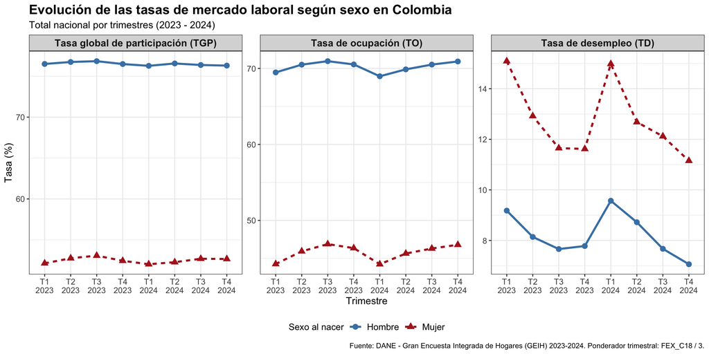

```r
datos_grafico_tasas <- tabla_indicadores_trim %>%
  mutate(
    SEXO         = ifelse(P3271 == 1, "Hombre", "Mujer"),
    PERIODO_TRIM = factor(PERIODO_TRIM, levels = orden_trimestres)
  ) %>%
  select(
    PERIODO_TRIM, SEXO,
    `Tasa global de participación (TGP)` = TGP,
    `Tasa de ocupación (TO)`             = TO,
    `Tasa de desempleo (TD)`             = TD
  ) %>%
  pivot_longer(
    cols      = c("Tasa global de participación (TGP)", "Tasa de ocupación (TO)", "Tasa de desempleo (TD)"),
    names_to  = "TASA",
    values_to = "VALOR"
  ) %>%
  mutate(
    TASA = factor(TASA, levels = c("Tasa global de participación (TGP)", "Tasa de ocupación (TO)", "Tasa de desempleo (TD)"))
  )

# Datos y ponderador: serie trimestral 2023-2024 expandida con FEX_TRIM = FEX_C18 / 3.
# Mapeo estético (aes): eje X = trimestre ordenado (PERIODO_TRIM), eje Y = valor porcentual (VALOR),
# y triple codificación redundante por sexo (color, shape y linetype) para accesibilidad e impresión.
grafico_tasas <- ggplot(
  datos_grafico_tasas,
  aes(x = PERIODO_TRIM, y = VALOR, group = SEXO, color = SEXO, shape = SEXO, linetype = SEXO)
) +
  # Capas geométricas: líneas de trayectoria temporal (geom_line) y marcadores puntuales por trimestre (geom_point)
  geom_line(linewidth = 1.2) +
  geom_point(size = 3) +
  # Facetas: paneles independientes por indicador (TGP, TO, TD) con escala libre en Y (free_y) debido a que TD tiene otro rango
  facet_wrap(~TASA, scales = "free_y", ncol = 3) +
  # Escala discreta en X: etiquetas compactas en dos líneas (T1..T4 y año) para evitar solapamiento horizontal
  scale_x_discrete(labels = c("T1\n2023", "T2\n2023", "T3\n2023", "T4\n2023", "T1\n2024", "T2\n2024", "T3\n2024", "T4\n2024")) +
  # Escala de color manual: paleta sobria de alto contraste (azul acero para hombres, rojo ladrillo para mujeres)
  scale_color_manual(values = c("Hombre" = "steelblue", "Mujer" = "firebrick")) +
  # Etiquetas del gráfico: título, subtítulo, ejes, leyenda unificada y fuente oficial
  labs(
    title    = "Evolución de las tasas de mercado laboral según sexo en Colombia",
    subtitle = "Total nacional por trimestres (2023 - 2024)",
    x        = "Trimestre",
    y        = "Tasa (%)",
    color    = "Sexo al nacer", shape = "Sexo al nacer", linetype = "Sexo al nacer",
    caption  = "Fuente: DANE - Gran Encuesta Integrada de Hogares (GEIH) 2023-2024. Ponderador trimestral: FEX_C18 / 3."
  ) +
  # Tema base y personalización tipográfica: fondo blanco con grilla suave (theme_bw) y leyenda inferior
  theme_bw() +
  theme(
    axis.text.x     = element_text(hjust = 0.5, size = 10),
    strip.text      = element_text(face = "bold", size = 12),
    axis.text.y     = element_text(size = 10),
    axis.title      = element_text(size = 12),
    legend.text     = element_text(size = 11),
    legend.title    = element_text(size = 11),
    legend.position = "bottom",
    plot.title      = element_text(face = "bold", size = 16),
    plot.subtitle   = element_text(size = 12)
  )

grafico_tasas
```

**Código R**

```r
# Exportación en alta resolución (300 DPI, formato apaisado 12 x 6 pulgadas para los 3 paneles)
ggsave(file.path(ruta_outputs, "2_2_tasas_sexo.png"), plot = grafico_tasas, width = 12, height = 6, dpi = 300)
```

**Interpretación macroeconómica:** * En participación, la TGP de los hombres oscila entre 76,27 % y 76,84 %, frente a 52,02 % a 53,07 % en las mujeres. La brecha trimestral va de 23,64 a 24,37 puntos porcentuales. En ocupación, la TO masculina varía entre 68,97 % y 70,96 %, y la femenina entre 44,23 % y 46,88 %; la brecha es de 24,08 a 25,22 puntos. * La TD femenina varía entre 11,15 % y 15,09 %, frente a 7,06 % a 9,57 % en hombres. La diferencia desfavorable para las mujeres se sitúa entre 3,84 y 5,91 puntos porcentuales. * Entre julio-septiembre y octubre-diciembre de 2024, la TD cae de 7,67 % a 7,06 % en hombres y de 12,12 % a 11,15 % en mujeres. La TO aumenta de 70,51 % a 70,92 % y de 46,30 % a 46,79 %, respectivamente, mientras la TGP disminuye ligeramente (76,37 % a 76,30 % y 52,69 % a 52,66 %). La caída del desempleo coincide con una mayor ocupación relativa a la PET y una menor participación: $\text{TD}=100(1-\text{TO}/\text{TGP})$. La serie no identifica causas sectoriales ni permite establecer un patrón estacional.

## 4.3 2.3 Población Ocupada según Formalidad (13 Ciudades, Diciembre 2024)

### 4.3.1 Implementación de la sintaxis oficial de informalidad del DANE

Se adapta la sintaxis oficial en SAS del DANE (`Código_SAS` del anexo `anex-GEIHEISS-oct-dic2024.xlsx`) para obtener `EI = 1` en empleo formal y `EI = 0` en informal. Se construyen `FORMAL`, `SALUD` y `PENSION` antes de `EI`. El contraste independiente coincide en `EI` para los 353.672 ocupados de 2024. `FORMAL` difiere en 11.911 empleados domésticos (0 en R y faltante en SAS), sin cambiar la clasificación final. Las variables de negocio describen forma de trabajo, registro y renovación, contabilidad, separación de gastos, tamaño y oficio.

**Código R**

```r
areas_13ciudades <- c(5, 8, 11, 13, 17, 23, 50, 52, 54, 66, 68, 73, 76)

ocupados_2024 <- GEIH_2024 %>%
  filter(OCI == 1) %>%
  mutate(
    OFICIO_C8_2D = if_else(!is.na(OFICIO_C8), substr(sprintf("%04d", as.integer(OFICIO_C8)), 1, 2), NA_character_),
    ANIOS = ANIO - 1,

    # 1. Clasificación de formalidad de la unidad económica (FORMAL: 1 = Formal, 0 = Informal)
    # Adaptación de las reglas del DANE: EI final contrastado con Código_SAS
    FORMAL = case_when(
      # Rama institucional formal por definición: administración pública (84) y organizaciones extraterritoriales (99)
      RAMA2D_R4 %in% c(84, 99) ~ 1,

      # A. Asalariados particulares y trabajadores sin remuneración en otras empresas (P6430 %in% c(1, 7))
      P6430 %in% c(1, 7) & P3045S1 == 1 ~ 1,
      P6430 %in% c(1, 7) & P3045S1 %in% c(2, 9) & P3046 == 1 ~ 1,
      P6430 %in% c(1, 7) & P3045S1 %in% c(2, 9) & P3046 == 2 ~ 0,
      P6430 %in% c(1, 7) & P3045S1 %in% c(2, 9) & P3046 == 9 & P3069 >= 4 ~ 1,
      P6430 %in% c(1, 7) & P3045S1 %in% c(2, 9) & P3046 == 9 & P3069 <= 3 ~ 0,

      # B. Posiciones con regla institucional directa sobre la unidad económica en sintaxis DANE
      P6430 == 2 ~ 1,
      P6430 %in% c(3, 6, 8) ~ 0,

      # C. Formas de trabajo distintas de negocio o finca (P6765 != 7)
      P6765 != 7 & P3065 == 1 ~ 1,
      P6765 != 7 & P3065 %in% c(2, 9) & P3066 == 1 ~ 1,
      P6765 != 7 & P3065 %in% c(2, 9) & P3066 == 2 ~ 0,
      P6765 != 7 & P3065 %in% c(2, 9) & P3066 == 9 & P6430 == 5 & P3069 >= 4 ~ 1,
      P6765 != 7 & P3065 %in% c(2, 9) & P3066 == 9 & P6430 == 5 & P3069 <= 3 ~ 0,
      P6765 != 7 & P3065 %in% c(2, 9) & P3066 == 9 & P6430 == 4 & OFICIO_C8_2D <= "20" ~ 1,
      P6765 != 7 & P3065 %in% c(2, 9) & P3066 == 9 & P6430 == 4 & OFICIO_C8_2D >= "21" ~ 0,

      # D. Negocio con registro mercantil renovado (P6765 == 7 & P3067 == 1 & P3067S1 == 1)
      P6765 == 7 & P3067 == 1 & P3067S1 == 1 & P3067S2 >= ANIOS ~ 1,
      P6765 == 7 & P3067 == 1 & P3067S1 == 1 & P3067S2 < ANIOS ~ 0,

      # E. Negocio con registro mercantil no renovado (P6765 == 7 & P3067 == 1 & P3067S1 == 2)
      P6765 == 7 & P3067 == 1 & P3067S1 == 2 & P6775 == 1 ~ 1,
      P6765 == 7 & P3067 == 1 & P3067S1 == 2 & P6775 == 2 ~ 0,
      P6765 == 7 & P3067 == 1 & P3067S1 == 2 & P6775 == 9 & P6430 == 5 & P3069 >= 4 ~ 1,
      P6765 == 7 & P3067 == 1 & P3067S1 == 2 & P6775 == 9 & P6430 == 5 & P3069 <= 3 ~ 0,
      P6765 == 7 & P3067 == 1 & P3067S1 == 2 & P6775 == 9 & P6430 == 4 & OFICIO_C8_2D <= "20" ~ 1,
      P6765 == 7 & P3067 == 1 & P3067S1 == 2 & P6775 == 9 & P6430 == 4 & OFICIO_C8_2D >= "21" ~ 0,
      P6765 == 7 & P3067 == 1 & P3067S1 == 2 & P6775 == 3 & OFICIO_C8_2D <= "20" ~ 1,
      P6765 == 7 & P3067 == 1 & P3067S1 == 2 & P6775 == 3 & OFICIO_C8_2D >= "21" ~ 0,

      # F. Negocio sin registro mercantil (P6765 == 7 & P3067 == 2)
      P6765 == 7 & P3067 == 2 & P6775 == 1 & P3068 == 1 ~ 1,
      P6765 == 7 & P3067 == 2 & P6775 == 1 & P3068 == 2 ~ 0,
      P6765 == 7 & P3067 == 2 & P6775 == 1 & P3068 %in% c(3, 9) ~ 0,
      P6765 == 7 & P3067 == 2 & P6775 == 2 ~ 0,
      P6765 == 7 & P3067 == 2 & P6775 == 9 & P6430 == 5 & P3069 >= 4 ~ 1,
      P6765 == 7 & P3067 == 2 & P6775 == 9 & P6430 == 5 & P3069 <= 3 ~ 0,
      P6765 == 7 & P3067 == 2 & P6775 == 9 & P6430 == 4 & OFICIO_C8_2D <= "20" ~ 1,
      P6765 == 7 & P3067 == 2 & P6775 == 9 & P6430 == 4 & OFICIO_C8_2D >= "21" ~ 0,
      P6765 == 7 & P3067 == 2 & P6775 == 3 & OFICIO_C8_2D <= "20" ~ 1,
      P6765 == 7 & P3067 == 2 & P6775 == 3 & OFICIO_C8_2D >= "21" ~ 0,

      TRUE ~ NA_real_
    ),

    # 2. Afiliación contributiva o especial a salud (SALUD: 1 = Formal, 0 = Informal)
    SALUD = case_when(
      P6430 %in% c(1, 3, 7) & P6100 %in% c(1, 2) & P6110 %in% c(1, 2, 4) ~ 1,
      P6430 %in% c(1, 3, 7) & (P6100 == 9 | P6110 == 9) & P6450 == 2 ~ 1,
      P6430 %in% c(1, 3, 7) ~ 0,
      TRUE ~ NA_real_
    ),

    # 3. Cotización a pensión o condición de pensionado (PENSION: 1 = Formal, 0 = Informal)
    PENSION = case_when(
      P6430 %in% c(1, 3, 7) & P6920 == 3 ~ 1,
      P6430 %in% c(1, 3, 7) & P6920 == 1 & P6930 %in% 1:3 & P6940 %in% c(1, 3) ~ 1,
      P6430 %in% c(1, 3, 7) ~ 0,
      TRUE ~ NA_real_
    ),

    # 4. Empleo formal / informal total (EI: 1 = Formal, 0 = Informal)
    EI = case_when(
      P6430 == 2 ~ 1,
      P6430 %in% c(6, 8) ~ 0,
      P6430 %in% c(4, 5) ~ FORMAL,
      P6430 %in% c(1, 3, 7) & SALUD == 1 & PENSION == 1 ~ 1,
      P6430 %in% c(1, 3, 7) ~ 0,
      TRUE ~ NA_real_
    )
  )

GEIH_13ciudades_tri <- ocupados_2024 %>%
  filter(MES %in% 10:12, as.numeric(AREA) %in% areas_13ciudades)

# Verificación de referencia DANE (42,5 % informalidad en 13 ciudades, Oct-Dic 2024)
control_ei_dane <- GEIH_13ciudades_tri %>%
  summarise(
    N_OCUPADOS             = n(),
    N_SIN_EI               = sum(is.na(EI)),
    INFORMALIDAD_CALCULADA = round(100 * sum((FEX_C18 / 3)[EI == 0], na.rm = TRUE) / sum((FEX_C18 / 3)[!is.na(EI)], na.rm = TRUE), 1),
    INFORMALIDAD_DANE      = 42.5,
    DIFERENCIA_PP          = round(INFORMALIDAD_CALCULADA - INFORMALIDAD_DANE, 1)
  )
write.csv(control_ei_dane, file.path(ruta_outputs, "2_3_control_ei_dane.csv"), row.names = FALSE)

# Filtrar Diciembre 2024 para el gráfico de torta
GEIH_13ciudades_dic <- GEIH_13ciudades_tri %>% filter(MES == 12)

tabla_formalidad_sexo <- GEIH_13ciudades_dic %>%
  filter(!is.na(EI), P3271 %in% c(1, 2), !is.na(FEX_C18)) %>%
  mutate(
    SEXO      = ifelse(P3271 == 1, "Hombre", "Mujer"),
    CONDICION = ifelse(EI == 1, "Formal", "Informal")
  ) %>%
  group_by(SEXO, CONDICION) %>%
  summarise(TOTAL_EXPANDIDO = sum(FEX_C18, na.rm = TRUE), .groups = "drop") %>%
  group_by(SEXO) %>%
  mutate(PORCENTAJE = round(TOTAL_EXPANDIDO / sum(TOTAL_EXPANDIDO) * 100, 1)) %>%
  ungroup()

write.csv(tabla_formalidad_sexo, file.path(ruta_outputs, "2_3_tabla_formalidad_13ciudades.csv"), row.names = FALSE)
```

**Código R**

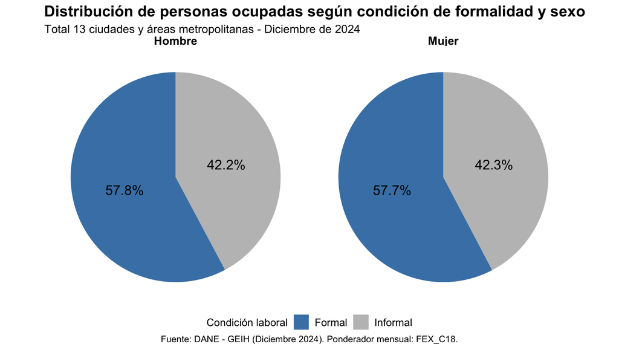

```r
# Datos y ponderador: ocupados de las 13 ciudades y A.M. en diciembre de 2024 expandidos con FEX_C18.
# Mapeo estético (aes): eje X vacío ("") para barra única, eje Y = porcentaje (PORCENTAJE), relleno (fill) = condición (CONDICION).
grafico_formalidad <- ggplot(tabla_formalidad_sexo, aes(x = "", y = PORCENTAJE, fill = CONDICION)) +
  # Capa geométrica de barras apiladas al 100 % que sirve de base para la transformación polar
  geom_col(width = 1) +
  # Coordenadas polares sobre el eje Y (theta = "y") para transformar la barra apilada en gráfico de torta
  coord_polar(theta = "y") +
  # Facetas por sexo para comparar lado a lado la composición porcentual de hombres y mujeres
  facet_wrap(~SEXO) +
  # Etiquetas de texto centradas en cada sector circular mediante position_stack(vjust = 0.5)
  geom_text(aes(label = paste0(PORCENTAJE, "%")), position = position_stack(vjust = 0.5), size = 5) +
  # Escala manual de relleno: azul acero para formalidad y gris claro para informalidad
  scale_fill_manual(values = c("Formal" = "steelblue", "Informal" = "grey75")) +
  # Títulos, subtítulo, leyenda y nota de fuente con el ponderador utilizado
  labs(
    title    = "Distribución de personas ocupadas según condición de formalidad y sexo",
    subtitle = "Total 13 ciudades y áreas metropolitanas - Diciembre de 2024",
    fill     = "Condición laboral",
    caption  = "Fuente: DANE - GEIH (Diciembre 2024). Ponderador mensual: FEX_C18."
  ) +
  # Tema vacío (theme_void) para eliminar ejes cartesianos innecesarios en coordenadas polares
  theme_void() +
  theme(
    legend.position = "bottom",
    legend.text     = element_text(size = 11),
    legend.title    = element_text(size = 11),
    strip.text      = element_text(size = 12, face = "bold"),
    plot.title      = element_text(size = 16, face = "bold"),
    plot.subtitle   = element_text(size = 12),
    plot.caption    = element_text(size = 9.5, hjust = 0.5)
  )

grafico_formalidad
```

**Código R**

```r
# Exportación del gráfico de torta en alta resolución (300 DPI)
ggsave(file.path(ruta_outputs, "2_3_formalidad_13ciudades.png"), plot = grafico_formalidad, width = 9, height = 5, dpi = 300)
```

**Verificación externa DANE:** El cálculo para el trimestre Oct-Dic 2024 arroja **42.5%**, con una discrepancia nula frente a la cifra oficial del DANE (**42,5 %**). En diciembre, la formalidad en las 13 áreas metropolitanas es mayoritaria tanto para hombres (57,8 % formal vs. 42,2 % informal) como para mujeres (57,7 % formal vs. 42,3 % informal).

## 4.4 2.4 Distribución según Posición Ocupacional (Enero 2023)

**Código R**

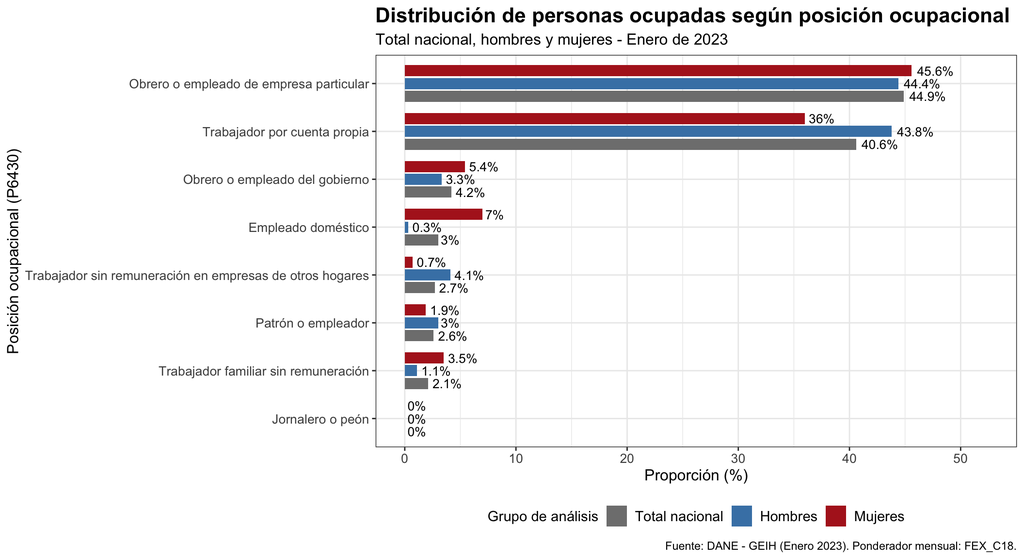

```r
GEIH_2023_ENE <- GEIH %>%
  filter(ANIO == 2023, MES == 1, OCI == 1, !is.na(P6430))

posicion_total <- GEIH_2023_ENE %>%
  group_by(P6430) %>%
  summarise(TOTAL_EXP = sum(FEX_C18, na.rm = TRUE), .groups = "drop") %>%
  mutate(GRUPO = "Total nacional", PORCENTAJE = round(TOTAL_EXP / sum(TOTAL_EXP) * 100, 1))

posicion_hombres <- GEIH_2023_ENE %>%
  filter(P3271 == 1) %>%
  group_by(P6430) %>%
  summarise(TOTAL_EXP = sum(FEX_C18, na.rm = TRUE), .groups = "drop") %>%
  mutate(GRUPO = "Hombres", PORCENTAJE = round(TOTAL_EXP / sum(TOTAL_EXP) * 100, 1))

posicion_mujeres <- GEIH_2023_ENE %>%
  filter(P3271 == 2) %>%
  group_by(P6430) %>%
  summarise(TOTAL_EXP = sum(FEX_C18, na.rm = TRUE), .groups = "drop") %>%
  mutate(GRUPO = "Mujeres", PORCENTAJE = round(TOTAL_EXP / sum(TOTAL_EXP) * 100, 1))

orden_posiciones <- posicion_total %>%
  left_join(etiquetas_posicion, by = "P6430") %>%
  arrange(TOTAL_EXP) %>%
  pull(POSICION_OCUPACIONAL)

posicion_consolidada <- bind_rows(posicion_total, posicion_hombres, posicion_mujeres) %>%
  left_join(etiquetas_posicion, by = "P6430") %>%
  mutate(
    POSICION_OCUPACIONAL = factor(POSICION_OCUPACIONAL, levels = orden_posiciones),
    GRUPO                = factor(GRUPO, levels = c("Total nacional", "Hombres", "Mujeres"))
  )

prop_cuenta_propia_patron <- posicion_total %>%
  filter(P6430 %in% c(4, 5)) %>%
  summarise(PORCENTAJE_CONJUNTO = sum(PORCENTAJE)) %>%
  pull(PORCENTAJE_CONJUNTO)

# Datos y ponderador: ocupados en enero de 2023 expandidos con FEX_C18 según las 9 categorías DANE de P6430.
# Mapeo estético (aes): eje X = posición ocupacional ordenada por peso nacional, eje Y = proporción (%), fill = grupo.
grafico_posicion <- ggplot(posicion_consolidada, aes(x = POSICION_OCUPACIONAL, y = PORCENTAJE, fill = GRUPO)) +
  # Barras agrupadas (position_dodge) para contrastar Total nacional, Hombres y Mujeres en cada categoría
  geom_col(position = position_dodge(width = 0.8), width = 0.7) +
  # Inversión de coordenadas (coord_flip) para lectura horizontal de las etiquetas completas del DANE
  coord_flip() +
  # Etiquetas de datos al extremo derecho de cada barra agrupada
  geom_text(aes(label = paste0(PORCENTAJE, "%")), position = position_dodge(width = 0.8), hjust = -0.15, size = 3.5) +
  # Ampliación del límite superior del eje Y (15 % adicional) para que las etiquetas de texto no se recorten
  scale_y_continuous(limits = c(0, max(posicion_consolidada$PORCENTAJE) * 1.15)) +
  # Escala manual de colores coherente con el resto del taller
  scale_fill_manual(values = c("Total nacional" = "grey50", "Hombres" = "steelblue", "Mujeres" = "firebrick")) +
  # Etiquetas descriptivas y fuente oficial
  labs(
    title    = "Distribución de personas ocupadas según posición ocupacional",
    subtitle = "Total nacional, hombres y mujeres - Enero de 2023",
    x        = "Posición ocupacional (P6430)",
    y        = "Proporción (%)",
    fill     = "Grupo de análisis",
    caption  = "Fuente: DANE - GEIH (Enero 2023). Ponderador mensual: FEX_C18."
  ) +
  # Tema limpio con grilla de referencia y leyenda inferior
  theme_bw() +
  theme(
    plot.title      = element_text(face = "bold", size = 16),
    plot.subtitle   = element_text(size = 12),
    axis.text.y     = element_text(size = 10),
    axis.text.x     = element_text(size = 10),
    axis.title      = element_text(size = 12),
    legend.text     = element_text(size = 11),
    legend.title    = element_text(size = 11),
    legend.position = "bottom"
  )

grafico_posicion
```

**Código R**

```r
# Exportación en alta resolución (300 DPI)
ggsave(file.path(ruta_outputs, "2_4_posicion_nacional.png"), plot = grafico_posicion, width = 11, height = 6, dpi = 300)
```

**Conexión analítica:** En conjunto, los trabajadores por cuenta propia (40,6 %) y los patrones o empleadores (2,6 %) concentran el **43.2%** de toda la ocupación en Colombia. Este dato es el fundamento conceptual directo del **Punto 3**: casi la mitad de los trabajadores colombianos operan como unidades económicas independientes, constituyendo el universo potencial que investiga la encuesta EMICRON.

# 5 Punto 3: Caracterización de Micronegocios en Colombia

## 5.1 3.1 Indicadores Básicos y Verificación con Boletín DANE (2024)

Todas las cifras de micronegocios se expanden con el ponderador anual `F_EXP`. Los porcentajes se calculan directamente con la suma exacta de `F_EXP` antes de redondear los totales expandidos (`TOTAL_SIN_REDONDEAR`), evitando errores de redondeo intermedio.

**Código R**

```r
# Total nacional
total_nacional_micros <- emicron %>%
  summarise(
    TOTAL_SIN_REDONDEAR = sum(F_EXP, na.rm = TRUE),
    TOTAL_EXPANDIDO     = round(TOTAL_SIN_REDONDEAR, 0)
  ) %>%
  mutate(INDICADOR = "Total nacional", CATEGORIA = "Total micronegocios", PORCENTAJE = 100.0) %>%
  select(INDICADOR, CATEGORIA, TOTAL_EXPANDIDO, PORCENTAJE)

# Distribución por rama (GRUPOS12)
distribucion_rama <- emicron %>%
  mutate(
    CATEGORIA = case_when(
      GRUPOS12 == 1  ~ "Agricultura, ganadería, caza, silvicultura y pesca",
      GRUPOS12 == 2  ~ "Explotación de minas y canteras",
      GRUPOS12 == 3  ~ "Industrias manufactureras",
      GRUPOS12 == 4  ~ "Construcción",
      GRUPOS12 == 5  ~ "Comercio y reparación de vehículos",
      GRUPOS12 == 6  ~ "Transporte y almacenamiento",
      GRUPOS12 == 7  ~ "Alojamiento y servicios de comida",
      GRUPOS12 == 8  ~ "Información y comunicaciones",
      GRUPOS12 == 9  ~ "Actividades inmobiliarias, profesionales y administrativas",
      GRUPOS12 == 10 ~ "Educación",
      GRUPOS12 == 11 ~ "Salud humana y asistencia social",
      GRUPOS12 == 12 ~ "Otras actividades de servicios comunitarios, sociales y personales",
      GRUPOS12 == 13 ~ "Actividades no clasificadas / Sin información",
      TRUE ~ "No informa"
    )
  ) %>%
  group_by(GRUPOS12, CATEGORIA) %>%
  summarise(TOTAL_SIN_REDONDEAR = sum(F_EXP, na.rm = TRUE), .groups = "drop") %>%
  mutate(
    INDICADOR       = "Distribución por rama de actividad (GRUPOS12)",
    PORCENTAJE      = round(TOTAL_SIN_REDONDEAR / sum(TOTAL_SIN_REDONDEAR) * 100, 1),
    TOTAL_EXPANDIDO = round(TOTAL_SIN_REDONDEAR, 0)
  ) %>%
  arrange(GRUPOS12) %>%
  select(INDICADOR, CATEGORIA, TOTAL_EXPANDIDO, PORCENTAJE)

# Distribución por sexo (P35)
distribucion_sexo <- emicron %>%
  mutate(CATEGORIA = case_when(P35 == 1 ~ "Hombre", P35 == 2 ~ "Mujer", TRUE ~ "No informa")) %>%
  group_by(CATEGORIA) %>%
  summarise(TOTAL_SIN_REDONDEAR = sum(F_EXP, na.rm = TRUE), .groups = "drop") %>%
  mutate(
    INDICADOR       = "Distribución según sexo del propietario (P35)",
    PORCENTAJE      = round(TOTAL_SIN_REDONDEAR / sum(TOTAL_SIN_REDONDEAR) * 100, 1),
    TOTAL_EXPANDIDO = round(TOTAL_SIN_REDONDEAR, 0)
  ) %>%
  select(INDICADOR, CATEGORIA, TOTAL_EXPANDIDO, PORCENTAJE)

# Formalidad tributaria: RUT (P1633)
distribucion_rut <- emicron %>%
  mutate(CATEGORIA = case_when(P1633 == 1 ~ "Cuenta con RUT", P1633 == 2 ~ "No cuenta con RUT", TRUE ~ "No informa")) %>%
  group_by(CATEGORIA) %>%
  summarise(TOTAL_SIN_REDONDEAR = sum(F_EXP, na.rm = TRUE), .groups = "drop") %>%
  mutate(
    INDICADOR       = "Registro Único Tributario - RUT (P1633)",
    PORCENTAJE      = round(TOTAL_SIN_REDONDEAR / sum(TOTAL_SIN_REDONDEAR) * 100, 1),
    TOTAL_EXPANDIDO = round(TOTAL_SIN_REDONDEAR, 0)
  ) %>%
  select(INDICADOR, CATEGORIA, TOTAL_EXPANDIDO, PORCENTAJE)

# Registro mercantil: Cámara de Comercio (P1055)
distribucion_camara <- emicron %>%
  mutate(CATEGORIA = case_when(P1055 == 1 ~ "Registrado ante Cámara de Comercio", P1055 == 2 ~ "No registrado", TRUE ~ "No informa")) %>%
  group_by(CATEGORIA) %>%
  summarise(TOTAL_SIN_REDONDEAR = sum(F_EXP, na.rm = TRUE), .groups = "drop") %>%
  mutate(
    INDICADOR       = "Registro ante Cámara de Comercio (P1055)",
    PORCENTAJE      = round(TOTAL_SIN_REDONDEAR / sum(TOTAL_SIN_REDONDEAR) * 100, 1),
    TOTAL_EXPANDIDO = round(TOTAL_SIN_REDONDEAR, 0)
  ) %>%
  select(INDICADOR, CATEGORIA, TOTAL_EXPANDIDO, PORCENTAJE)

tabla_indicadores_micros <- bind_rows(
  total_nacional_micros, distribucion_sexo, distribucion_rama, distribucion_rut, distribucion_camara
)
write.xlsx(tabla_indicadores_micros, file.path(ruta_outputs, "3_1_indicadores.xlsx"))

# Comparación calculada frente al Boletín Técnico DANE (Gráfico 9 y Tabla 8)
camara_exacto_pct <- emicron %>%
  summarise(PCT_EXACTO = sum(F_EXP[P1055 == 1], na.rm = TRUE) / sum(F_EXP, na.rm = TRUE) * 100) %>%
  pull(PCT_EXACTO)

verificacion_3_1_dane <- data.frame(
  INDICADOR = c(
    "Total nacional de micronegocios (unidades)",
    "Propietarios hombres (%)",
    "Propietarias mujeres (%)",
    "Micronegocios con RUT (%)",
    "Micronegocios con Cámara de Comercio (%) - Gráfico 9 Boletín",
    "Micronegocios con Cámara de Comercio (%) - Tabla 8"
  ),
  VALOR_CALCULADO = c(
    total_nacional_micros$TOTAL_EXPANDIDO,
    distribucion_sexo$PORCENTAJE[distribucion_sexo$CATEGORIA == "Hombre"],
    distribucion_sexo$PORCENTAJE[distribucion_sexo$CATEGORIA == "Mujer"],
    distribucion_rut$PORCENTAJE[distribucion_rut$CATEGORIA == "Cuenta con RUT"],
    distribucion_camara$PORCENTAJE[distribucion_camara$CATEGORIA == "Registrado ante Cámara de Comercio"],
    round(camara_exacto_pct, 3)
  ),
  VALOR_PUBLICADO_DANE = c(
    5297252,
    64.6,
    35.4,
    22.4,
    10.5,
    round(547581 / 5297252 * 100, 3)
  )
) %>%
  mutate(DIFERENCIA = round(VALOR_CALCULADO - VALOR_PUBLICADO_DANE, 3))
```

Comparación calculada de indicadores básicos frente al Boletín Técnico DANE (EMICRON 2024)

| INDICADOR | VALOR_CALCULADO | VALOR_PUBLICADO_DANE | DIFERENCIA |
| --- | --- | --- | --- |
| Total nacional de micronegocios (unidades) | 5297252.000 | 5297252.000 | 0.0 |
| Propietarios hombres (%) | 64.600 | 64.600 | 0.0 |
| Propietarias mujeres (%) | 35.400 | 35.400 | 0.0 |
| Micronegocios con RUT (%) | 22.400 | 22.400 | 0.0 |
| Micronegocios con Cámara de Comercio (%) - Gráfico 9 Boletín | 10.300 | 10.500 | -0.2 |
| Micronegocios con Cámara de Comercio (%) - Tabla 8 | 10.337 | 10.337 | 0.0 |

**Verificación frente al boletín técnico del DANE (EMICRON 2024):** - **Total micronegocios:** **5.297.252** unidades expandidas, coincidencia con la cifra publicada por el DANE. - **Sexo del propietario y RUT:** Hombres **64,6 %** y mujeres **35,4 %**; tenencia de RUT **22,4 %** (frente a **77,6 %** sin RUT), coincidiendo a un decimal con las cifras del boletín. - **Cámara de Comercio (`P1055 == 1`):** El porcentaje calculado con `F_EXP` antes de redondear es **10,3 %** (`10,337 %` exacto: $547.580,7 / 5.297.252,1$, y **89,7 %** sin registro), mientras que el **Gráfico 9** del boletín técnico del DANE reporta **10,5 %** (y **89,5 %** sin registro), lo que arroja una diferencia de **$-0,2$ puntos porcentuales**. Al contrastar la **Tabla 8** del mismo boletín oficial, las cantidades publicadas por el DANE ($547.581$ micronegocios con registro mercantil sobre $5.297.252$ totales) producen exactamente $\frac{547.581}{5.297.252} = 10,337\,\%$ (**10,3 %**), la diferencia con el Gráfico 9 no se explica por redondeo. No se identificó documentalmente la causa de esa discrepancia.

## 5.2 3.2 Inclusión Financiera de los Micronegocios

### 5.2.1 Tratamiento iterativo de preguntas multirrespuesta

Se procesan las 7 variables dicotómicas de medios de pago (`P1764_1` a `P1764_7`) mediante un bucle de iteración sin código redundante, desagregando por `GRUPOS4` (Agropecuario, Industria, Comercio y Servicios).

**Código R**

```r
base_inclusion <- emicron %>% filter(GRUPOS4 %in% 1:4) # Excluimos registros sin clasificación en las 4 macrorramas (GRUPOS4 == 5)

diccionario_formas <- data.frame(
  VARIABLE   = paste0("P1764_", 1:7),
  FORMA_PAGO = c("Efectivo", "Cheque", "Transferencia bancaria / Internet", "Factura a crédito", "Tarjeta débito", "Tarjeta crédito", "Otros")
)

lista_formas_pago <- list()
for (variable_pago in diccionario_formas$VARIABLE) {
  lista_formas_pago[[variable_pago]] <- base_inclusion %>%
    group_by(GRUPOS4) %>%
    summarise(
      VARIABLE   = variable_pago,
      PORCENTAJE = round(sum(if_else(!is.na(.data[[variable_pago]]) & .data[[variable_pago]] == 1, F_EXP, 0), na.rm = TRUE) / sum(F_EXP, na.rm = TRUE) * 100, 1),
      .groups    = "drop"
    )
}

tabla_formas_pago <- bind_rows(lista_formas_pago) %>%
  left_join(diccionario_formas, by = "VARIABLE") %>%
  mutate(
    RAMA       = case_when(
      GRUPOS4 == 1 ~ "Agropecuario",
      GRUPOS4 == 2 ~ "Industria",
      GRUPOS4 == 3 ~ "Comercio",
      GRUPOS4 == 4 ~ "Servicios",
      TRUE ~ NA_character_
    ),
    # Transformación a factor ordenado para preservar la jerarquía visual en el gráfico 3.2.4
    FORMA_PAGO = factor(FORMA_PAGO, levels = diccionario_formas$FORMA_PAGO),
    RAMA       = factor(RAMA, levels = c("Agropecuario", "Industria", "Comercio", "Servicios"))
  )

indicadores_credito_ahorro <- base_inclusion %>%
  summarise(
    SOLICITO_CREDITO_PCT = round(sum(if_else(!is.na(P1765) & P1765 == 1, F_EXP, 0), na.rm = TRUE) / sum(if_else(!is.na(P1765), F_EXP, 0), na.rm = TRUE) * 100, 1),
    AHORRO_PCT           = round(sum(if_else(!is.na(P3014) & P3014 == 1, F_EXP, 0), na.rm = TRUE) / sum(if_else(!is.na(P3014), F_EXP, 0), na.rm = TRUE) * 100, 1)
  )
write.csv(indicadores_credito_ahorro, file.path(ruta_outputs, "3_2_credito_ahorro.csv"), row.names = FALSE)
```

**Código R**

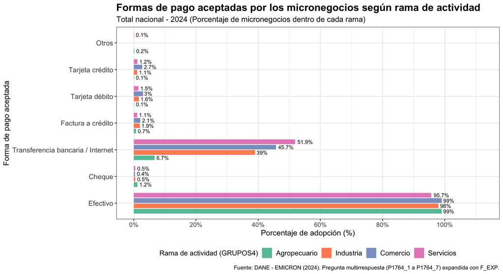

```r
# Datos y ponderador: micronegocios clasificados en GRUPOS4 (1:4) expandidos con el factor anual F_EXP.
# Mapeo estético (aes): eje X = forma de pago (FORMA_PAGO), eje Y = porcentaje de adopción dentro de la rama (PORCENTAJE),
# y relleno (fill) = macrorrama de actividad económica (RAMA).
grafico_formas_pago <- ggplot(tabla_formas_pago, aes(x = FORMA_PAGO, y = PORCENTAJE, fill = RAMA)) +
  # Capa geométrica de barras agrupadas lado a lado (position_dodge) para comparar las 4 ramas en cada medio de pago
  geom_col(position = position_dodge(width = 0.8), width = 0.7) +
  # Capa de etiquetas de texto: muestra el porcentaje solo cuando es mayor a 0 % para evitar saturación visual
  geom_text(aes(label = ifelse(PORCENTAJE > 0, paste0(PORCENTAJE, "%"), "")), position = position_dodge(width = 0.8), hjust = -0.15, size = 3) +
  # Escala continua del eje Y: límites entre 0 y 112 % (margen para etiquetas) con marcas cada 20 puntos porcentuales
  scale_y_continuous(limits = c(0, 112), breaks = seq(0, 100, 20), labels = paste0(seq(0, 100, 20), "%")) +
  # Coordenadas volteadas (coord_flip) para desplegar las barras horizontalmente y facilitar la lectura de las categorías
  coord_flip() +
  # Escala cromática cualitativa ColorBrewer "Set2" para diferenciar las cuatro ramas de actividad
  scale_fill_brewer(palette = "Set2") +
  # Etiquetas descriptivas: título, subtítulo explicativo del denominador por rama, ejes, leyenda y nota técnica
  labs(
    title    = "Formas de pago aceptadas por los micronegocios según rama de actividad",
    subtitle = "Total nacional - 2024 (Porcentaje de micronegocios dentro de cada rama)",
    x        = "Forma de pago aceptada",
    y        = "Porcentaje de adopción (%)",
    fill     = "Rama de actividad (GRUPOS4)",
    caption  = "Fuente: DANE - EMICRON (2024). Pregunta multirrespuesta (P1764_1 a P1764_7) expandida con F_EXP."
  ) +
  # Tema base blanco y negro (theme_bw) y ajustes tipográficos de títulos, ejes y leyenda en la parte inferior
  theme_bw() +
  theme(
    plot.title      = element_text(face = "bold", size = 16),
    plot.subtitle   = element_text(size = 12),
    axis.text.x     = element_text(size = 10),
    axis.text.y     = element_text(size = 11),
    axis.title      = element_text(size = 12),
    legend.text     = element_text(size = 11),
    legend.title    = element_text(size = 11),
    legend.position = "bottom"
  )

grafico_formas_pago
```

**Código R**

```r
# Exportación en alta resolución (300 DPI, 11 x 6 pulgadas)
ggsave(file.path(ruta_outputs, "3_2_formas_pago.png"), plot = grafico_formas_pago, width = 11, height = 6, dpi = 300)
```

## 5.3 3.3 Análisis Conjunto GEIH – EMICRON: Capital Humano y Formalidad Tributaria

### 5.3.1 Pregunta de investigación, auditoría de códigos y categorías explícitas del DANE

**Pregunta:** *¿Existe una asociación entre el nivel educativo alcanzado por el propietario del micronegocio (medido en GEIH: `P3042`) y la formalización tributaria de la unidad económica (medida en EMICRON: `P1633`, tenencia de RUT)?*

**Delimitación y ponderación:** - Universo: Propietarios de micronegocios emparejados exitosamente entre GEIH y EMICRON (`71.754` propietarios; `4.864.444` micronegocios expandidos). - Ventana temporal efectiva: Febrero a diciembre de 2024 (excluyendo enero debido al desfase de recolección demostrado en 1.4). - Ponderador exclusivo: `F_EXP`. - Categorías educativas: Se utilizan explícitamente las **13 categorías de niveles conocidos del diccionario GEIH 2024** (`P3042 == 1` a `P3042 == 13`), identificando y auditando previamente el código `99` (*No sabe, no informa*), valores faltantes (`NA`) y códigos inválidos.

**Código R**

```r
# Auditoría explícita de códigos de P3042 (1:13, 99, NA e inválidos) y P1633 en propietarios emparejados
auditoria_educacion_3_3 <- base_micro %>%
  filter(EMPAREJADO) %>%
  summarise(
    TOTAL_EMPAREJADOS     = n(),
    P3042_CONOCIDOS_1_13  = sum(P3042 %in% 1:13, na.rm = TRUE),
    P3042_NO_SABE_99      = sum(P3042 == 99, na.rm = TRUE),
    P3042_NA              = sum(is.na(P3042)),
    P3042_INVALIDOS       = sum(!is.na(P3042) & !(P3042 %in% c(1:13, 99))),
    P1633_VALIDOS_1_2     = sum(P1633 %in% c(1, 2), na.rm = TRUE),
    P1633_NO_INFORMA_O_NA = sum(is.na(P1633) | !(P1633 %in% c(1, 2)))
  )
print(auditoria_educacion_3_3)
```

```
  TOTAL_EMPAREJADOS P3042_CONOCIDOS_1_13 P3042_NO_SABE_99 P3042_NA
1             71754                71754                0        0
  P3042_INVALIDOS P1633_VALIDOS_1_2 P1633_NO_INFORMA_O_NA
1               0             71754                     0
```

**Código R**

```r
niveles_dane_p3042 <- c(
  "Ninguno",
  "Preescolar",
  "Básica primaria (1o - 5o)",
  "Básica secundaria (6o - 9o)",
  "Media académica (Bachillerato clásico)",
  "Media técnica (Bachillerato técnico)",
  "Normalista",
  "Técnica profesional",
  "Tecnológica",
  "Universitaria",
  "Especialización",
  "Maestría",
  "Doctorado"
)

datos_cruce <- base_micro %>%
  filter(EMPAREJADO) %>%
  mutate(
    NIVEL_EDUCATIVO = case_when(
      P3042 == 1  ~ "Ninguno",
      P3042 == 2  ~ "Preescolar",
      P3042 == 3  ~ "Básica primaria (1o - 5o)",
      P3042 == 4  ~ "Básica secundaria (6o - 9o)",
      P3042 == 5  ~ "Media académica (Bachillerato clásico)",
      P3042 == 6  ~ "Media técnica (Bachillerato técnico)",
      P3042 == 7  ~ "Normalista",
      P3042 == 8  ~ "Técnica profesional",
      P3042 == 9  ~ "Tecnológica",
      P3042 == 10 ~ "Universitaria",
      P3042 == 11 ~ "Especialización",
      P3042 == 12 ~ "Maestría",
      P3042 == 13 ~ "Doctorado",
      P3042 == 99 ~ "No sabe, no informa",
      is.na(P3042) ~ "Faltante (NA)",
      TRUE ~ "Código inválido"
    ),
    TIENE_RUT = case_when(
      P1633 == 1 ~ "Con RUT",
      P1633 == 2 ~ "Sin RUT",
      TRUE ~ "No informa"
    )
  ) %>%
  # Se excluyen del cruce analítico los códigos 99 ("No sabe, no informa"), faltantes (NA) e inválidos
  filter(P3042 %in% 1:13, P1633 %in% c(1, 2)) %>%
  mutate(
    NIVEL_EDUCATIVO = factor(NIVEL_EDUCATIVO, levels = niveles_dane_p3042),
    TIENE_RUT       = factor(TIENE_RUT, levels = c("Sin RUT", "Con RUT"))
  )

tabla_contingencia_cruce <- datos_cruce %>%
  group_by(NIVEL_EDUCATIVO, TIENE_RUT) %>%
  summarise(
    N_MUESTRA           = n(),
    TOTAL_SIN_REDONDEAR = sum(F_EXP, na.rm = TRUE),
    .groups = "drop"
  ) %>%
  complete(
    NIVEL_EDUCATIVO,
    TIENE_RUT,
    fill = list(N_MUESTRA = 0L, TOTAL_SIN_REDONDEAR = 0)
  ) %>%
  group_by(NIVEL_EDUCATIVO) %>%
  mutate(
    TOTAL_NIVEL_SIN_REDONDEAR = sum(TOTAL_SIN_REDONDEAR),
    PORCENTAJE                = round(TOTAL_SIN_REDONDEAR / TOTAL_NIVEL_SIN_REDONDEAR * 100, 1),
    TOTAL_EXPANDIDO           = round(TOTAL_SIN_REDONDEAR, 0),
    TOTAL_NIVEL               = round(TOTAL_NIVEL_SIN_REDONDEAR, 0)
  ) %>%
  ungroup() %>%
  select(NIVEL_EDUCATIVO, TIENE_RUT, N_MUESTRA, TOTAL_EXPANDIDO, TOTAL_NIVEL, PORCENTAJE)

write.csv(tabla_contingencia_cruce, file.path(ruta_outputs, "3_3_tabla_educacion_rut.csv"), row.names = FALSE)
```

**Código R**

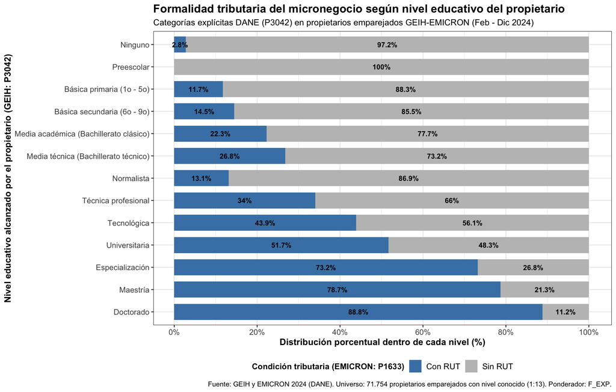

```r
# Datos y ponderador: 71.754 propietarios emparejados GEIH-EMICRON con nivel educativo conocido (1:13),
# expandidos con F_EXP (4.864.444 micronegocios).
# Mapeo estético (aes): se invierte el orden de los niveles en el eje vertical (rev(levels(...)))
# para que, al aplicar coord_flip(), "Ninguno" aparezca arriba y "Doctorado" abajo.
grafico_cruce <- ggplot(
  tabla_contingencia_cruce %>%
    mutate(NIVEL_EDUCATIVO_PLOT = factor(NIVEL_EDUCATIVO, levels = rev(niveles_dane_p3042))),
  aes(x = NIVEL_EDUCATIVO_PLOT, y = PORCENTAJE, fill = TIENE_RUT)
) +
  # Capa de barras apiladas al 100 % para comparar la composición tributaria dentro de cada nivel educativo
  geom_col(position = "stack", width = 0.72) +
  # Etiquetas de texto centradas en cada segmento; se ocultan valores iguales a 0 % (p. ej. Preescolar - Con RUT)
  geom_text(
    aes(label = ifelse(PORCENTAJE > 0, paste0(PORCENTAJE, "%"), "")),
    position = position_stack(vjust = 0.5),
    fontface = "bold",
    size = 3.2
  ) +
  # Inversión de coordenadas (coord_flip) para lectura horizontal íntegra de las 13 categorías del DANE
  coord_flip() +
  # Escala continua del eje porcentual de 0 % a 100 % con marcas cada 20 puntos porcentuales
  scale_y_continuous(limits = c(0, 100.5), breaks = seq(0, 100, 20), labels = paste0(seq(0, 100, 20), "%")) +
  # Escala manual de colores: azul acero para micronegocios con RUT y gris claro para sin RUT
  scale_fill_manual(values = c("Con RUT" = "steelblue", "Sin RUT" = "grey75"), breaks = c("Con RUT", "Sin RUT")) +
  # Títulos, ejes, leyenda y nota metodológica
  labs(
    title    = "Formalidad tributaria del micronegocio según nivel educativo del propietario",
    subtitle = "Categorías explícitas DANE (P3042) en propietarios emparejados GEIH-EMICRON (Feb - Dic 2024)",
    x        = "Nivel educativo alcanzado por el propietario (GEIH: P3042)",
    y        = "Distribución porcentual dentro de cada nivel (%)",
    fill     = "Condición tributaria (EMICRON: P1633)",
    caption  = "Fuente: GEIH y EMICRON 2024 (DANE). Universo: 71.754 propietarios emparejados con nivel conocido (1:13). Ponderador: F_EXP."
  ) +
  # Tema blanco y negro con leyenda inferior y tipografía legible para las 13 categorías
  theme_bw() +
  theme(
    plot.title      = element_text(face = "bold", size = 14.5),
    plot.subtitle   = element_text(size = 11),
    axis.text.x     = element_text(size = 10),
    axis.text.y     = element_text(size = 10),
    axis.title      = element_text(size = 11.5, face = "bold"),
    legend.text     = element_text(size = 10.5),
    legend.title    = element_text(size = 10.5, face = "bold"),
    legend.position = "bottom"
  )

grafico_cruce
```

**Código R**

```r
# Exportación en alta resolución (300 DPI, 11 x 7 pulgadas para alojar las 13 barras horizontales)
ggsave(file.path(ruta_outputs, "3_3_cruce.png"), plot = grafico_cruce, width = 11, height = 7, dpi = 300)
```

**Interpretación y factores explicativos no causales:** - La auditoría confirma que los `71.754` propietarios emparejados tienen niveles educativos conocidos en `1:13` (`0` en `99 = No sabe, no informa`, `0` faltantes y `0` códigos inválidos). - La proporción de micronegocios con RUT muestra una asociación positiva general, con excepciones entre categorías sucesivas: pasa de **0,0 %** en *Preescolar* ($n=6$) y **2,8 %** en *Ninguno*, a **11,7 %** en *Básica primaria (1o - 5o)*, **13,1 %** en *Normalista*, **14,5 %** en *Básica secundaria (6o - 9o)*, **22,3 %** en *Media académica* y **26,8 %** en *Media técnica*. Los porcentajes en educación superior y posgrado son: **34,0 %** en *Técnica profesional*, **43,9 %** en *Tecnológica*, **51,7 %** en *Universitaria*, **73,2 %** en *Especialización*, **78,7 %** en *Maestría* y **88,8 %** en *Doctorado*. - *Límites interpretativos:* Este gradiente describe una **asociación estadística**, pero no debe interpretarse como una relación causal directa. Dos hipótesis que podrían explicar la asociación, sin identificar causalidad, son: 1. **Escala del negocio:** Los negocios de mayor tamaño podrían combinar propietarios con mayor escolaridad y mayor registro tributario. Este cruce no prueba esa explicación. 2. **Composición sectorial:** La participación en actividades profesionales podría asociarse tanto con educación como con RUT. Verificarlo requeriría controlar por rama y otras características.

# 6 Punto 4: Análisis Socioeconómico Libre (GEIH 2024)

## 6.1 4.1 Geografía de la Informalidad y Dispersión Salarial Departamental

### 6.1.1 Pregunta y variables

Se analiza el dualismo centro-periferia en Colombia contrastando la tasa de informalidad laboral departamental con el ingreso laboral mediano mensual (`INGLABO`), utilizando una unidad geográfica subnacional (`DPTO`).

**Código R**

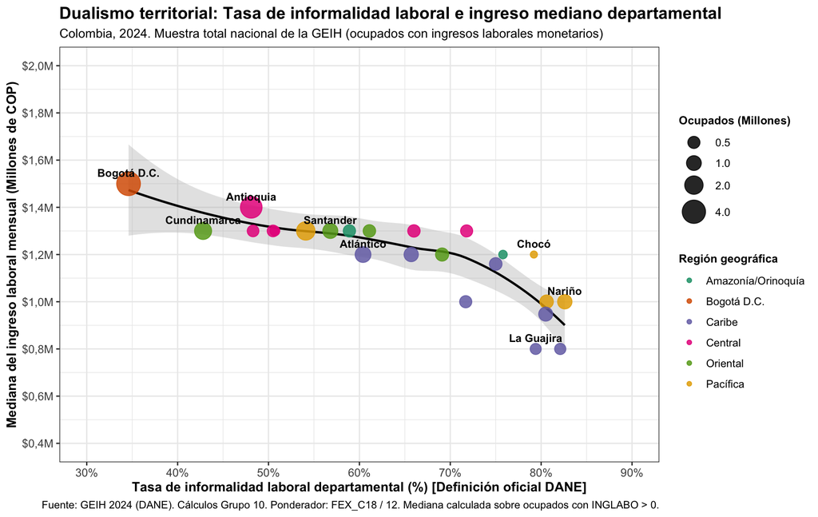

```r
# Reutilizamos la base ocupados_2024 con la variable de formalidad (EI) ya clasificada en el numeral 2.3.1
ocupados_2024_analisis <- ocupados_2024

dicc_deptos <- data.frame(
  DPTO_COD    = c(5, 8, 11, 13, 15, 17, 18, 19, 20, 23, 25, 27, 41, 44, 47, 50, 52, 54, 63, 66, 68, 70, 73, 76),
  NOMBRE_DPTO = c(
    "Antioquia", "Atlántico", "Bogotá D.C.", "Bolívar", "Boyacá", "Caldas",
    "Caquetá", "Cauca", "Cesar", "Córdoba", "Cundinamarca", "Chocó",
    "Huila", "La Guajira", "Magdalena", "Meta", "Nariño", "Norte de Santander",
    "Quindío", "Risaralda", "Santander", "Sucre", "Tolima", "Valle del Cauca"
  ),
  REGION      = c(
    "Central", "Caribe", "Bogotá D.C.", "Caribe", "Oriental", "Central",
    "Amazonía/Orinoquía", "Pacífica", "Caribe", "Caribe", "Oriental", "Pacífica",
    "Central", "Caribe", "Caribe", "Amazonía/Orinoquía", "Pacífica", "Oriental",
    "Central", "Central", "Oriental", "Caribe", "Central", "Pacífica"
  )
)

datos_deptos <- ocupados_2024_analisis %>%
  mutate(DPTO_NUM = as.numeric(DPTO)) %>%
  filter(!is.na(EI), DPTO_NUM %in% dicc_deptos$DPTO_COD) %>%
  group_by(DPTO_NUM) %>%
  summarise(
    OCUPADOS_EXP      = sum(FEX_C18 / 12, na.rm = TRUE),
    INFORMALES_EXP    = sum((FEX_C18 / 12)[EI == 0], na.rm = TRUE),
    TASA_INFORMALIDAD = round(INFORMALES_EXP / OCUPADOS_EXP * 100, 1),
    INGRESO_MEDIANO   = round(median(INGLABO[INGLABO > 0], na.rm = TRUE), 0),
    .groups           = "drop"
  ) %>%
  left_join(dicc_deptos, by = c("DPTO_NUM" = "DPTO_COD"))

write.csv(datos_deptos, file.path(ruta_outputs, "4_1_tabla_departamental.csv"), row.names = FALSE)

# Selección de 10 departamentos representativos de los extremos y centros urbanos para etiquetado directo
deptos_etiqueta <- datos_deptos %>%
  filter(NOMBRE_DPTO %in% c("Bogotá D.C.", "Antioquia", "Valle del Cauca", "Atlántico", "Chocó", "La Guajira", "Nariño", "Sucre", "Santander", "Cundinamarca"))

# Datos y ponderador: 24 dominios departamentales GEIH 2024 con tasa de informalidad expandida (FEX_C18 / 12)
# y mediana muestral de ingresos laborales monetarios positivos (INGLABO > 0).
# Mapeo estético (aes): eje X = tasa de informalidad (%), eje Y = ingreso mediano en millones de COP.
grafico_4_1 <- ggplot(datos_deptos, aes(x = TASA_INFORMALIDAD, y = INGRESO_MEDIANO / 1e6)) +
  # Capa de suavizado no paramétrico (LOESS) con banda de confianza al 95 % para capturar la relación inversa
  geom_smooth(method = "loess", se = TRUE, alpha = 0.35, linewidth = 0.9, color = "black", fill = "grey70") +
  # Capa de burbujas (geom_point): tamaño proporcional al volumen de ocupados (millones) y color por macrorregión
  geom_point(aes(size = OCUPADOS_EXP / 1e6, color = REGION), alpha = 0.85) +
  # Etiquetas de texto para los 10 departamentos seleccionados con control de solapamiento (check_overlap = TRUE)
  geom_text(data = deptos_etiqueta, aes(label = NOMBRE_DPTO), vjust = -0.9, size = 3.2, fontface = "bold", check_overlap = TRUE) +
  # Escala continua de tamaño de burbuja (entre 2,5 y 9 mm) y paleta cualitativa ColorBrewer "Dark2"
  scale_size_continuous(range = c(2.5, 9), breaks = c(0.5, 1, 2, 4)) +
  scale_color_brewer(palette = "Dark2") +
  # Escalas continuas en X (30 % a 90 %) e Y ($0,4M a $2,0M COP)
  scale_x_continuous(limits = c(30, 90), breaks = seq(30, 90, 10), labels = paste0(seq(30, 90, 10), "%")) +
  scale_y_continuous(limits = c(0.4, 2.0), breaks = seq(0.4, 2.0, 0.2), labels = paste0("$", c("0,4", "0,6", "0,8", "1,0", "1,2", "1,4", "1,6", "1,8", "2,0"), "M")) +
  # Títulos, ejes, leyendas y nota metodológica
  labs(
    title    = "Dualismo territorial: Tasa de informalidad laboral e ingreso mediano departamental",
    subtitle = "Colombia, 2024. Muestra total nacional de la GEIH (ocupados con ingresos laborales monetarios)",
    x        = "Tasa de informalidad laboral departamental (%) [Definición oficial DANE]",
    y        = "Mediana del ingreso laboral mensual (Millones de COP)",
    size     = "Ocupados (Millones)",
    color    = "Región geográfica",
    caption  = "Fuente: GEIH 2024 (DANE). Cálculos Grupo 10. Ponderador: FEX_C18 / 12. Mediana calculada sobre ocupados con INGLABO > 0."
  ) +
  # Tema blanco y negro con leyenda lateral derecha
  theme_bw() +
  theme(
    plot.title      = element_text(face = "bold", size = 14),
    plot.subtitle   = element_text(size = 10.5),
    axis.text       = element_text(size = 9.5),
    axis.title      = element_text(size = 11, face = "bold"),
    legend.position = "right",
    legend.title    = element_text(size = 9.5, face = "bold"),
    legend.text     = element_text(size = 9)
  )

grafico_4_1
```

**Código R**

```r
# Exportación en alta resolución (300 DPI)
ggsave(file.path(ruta_outputs, "4_1_geografia_informalidad.png"), plot = grafico_4_1, width = 9.5, height = 6, dpi = 300)
```

**Interpretación:** Los datos departamentales muestran una relación inversa entre informalidad e ingreso laboral (`4_1_tabla_departamental.csv`). En Bogotá la informalidad es de 34,6 % y la mediana muestral del ingreso mensual positivo es de 1,5 millones de pesos; en Chocó, de 79,2 % y 1,2 millones; en La Guajira, de 79,4 % y 800.000 pesos; y en Sucre, de 82,1 % y 800.000 pesos. Las tasas se expanden con `FEX_C18 / 12`, mientras que las medianas son estadísticas muestrales sin ponderar de ocupados con ingreso positivo y `EI` conocido. La comparación describe diferencias territoriales y no identifica sus causas.

## 6.2 4.2 Inclusión Financiera Digital y Escala de Ventas en Micronegocios

### 6.2.1 Pregunta, corrección de variables y contabilización de no respuesta

A partir de `base_micro`, se examina cómo varía la distribución de ventas brutas mensuales (`VENTAS_MES_ANTERIOR > 0`) según el perfil de medios de pago y la solicitud de crédito: - **Transferencias bancarias / internet (`P1764_3 == 1`):** según el diccionario oficial de EMICRON 2024, `P1764_3` identifica transferencias bancarias o por internet (mientras que `P1764_2` corresponde a cheque). - **Solo efectivo (efectivo exclusivo):** micronegocios que aceptan efectivo (`P1764_1 == 1`) y ningún otro medio seleccionado entre `P1764_2` y `P1764_7`. - **Solicitud de crédito (`P1765`):** mide si solicitó crédito para el negocio (`1 = Solicitó crédito`, `2 = No solicitó crédito`, `NA = No informa solicitud`). Se contabiliza explícitamente la no respuesta antes de graficar los 4 perfiles válidos.

**Código R**

```r
datos_micros_todos <- base_micro %>%
  filter(!is.na(VENTAS_MES_ANTERIOR), VENTAS_MES_ANTERIOR > 0, !is.na(F_EXP), F_EXP > 0) %>%
  mutate(
    OTROS_MEDIOS_DISTINTOS_EFECTIVO = (!is.na(P1764_2) & P1764_2 == 1) |
      (!is.na(P1764_3) & P1764_3 == 1) |
      (!is.na(P1764_4) & P1764_4 == 1) |
      (!is.na(P1764_5) & P1764_5 == 1) |
      (!is.na(P1764_6) & P1764_6 == 1) |
      (!is.na(P1764_7) & P1764_7 == 1),
    ADOPCION_DIGITAL = case_when(
      !is.na(P1764_3) & P1764_3 == 1 ~ "Transferencias bancarias / internet",
      !is.na(P1764_1) & P1764_1 == 1 & !OTROS_MEDIOS_DISTINTOS_EFECTIVO ~ "Solo efectivo",
      TRUE ~ "Otro perfil de pago"
    ),
    ACCESO_CREDITO = case_when(
      P1765 == 1 ~ "Solicitó crédito",
      P1765 == 2 ~ "No solicitó crédito",
      is.na(P1765) ~ "No informa solicitud (NA)",
      TRUE ~ "Código inválido"
    ),
    VENTAS_MILLONES = VENTAS_MES_ANTERIOR / 1e6
  )

# Contabilización explícita de perfiles de pago y no respuesta en P1765
auditoria_inclusion_4_2 <- datos_micros_todos %>%
  group_by(ADOPCION_DIGITAL, ACCESO_CREDITO) %>%
  summarise(
    N_MUESTRA        = n(),
    TOTAL_MICROS_EXP = round(sum(F_EXP, na.rm = TRUE), 0),
    .groups = "drop"
  )
print(auditoria_inclusion_4_2)
```

```
# A tibble: 9 × 4
  ADOPCION_DIGITAL                    ACCESO_CREDITO  N_MUESTRA TOTAL_MICROS_EXP
  <chr>                               <chr>               <int>            <dbl>
1 Otro perfil de pago                 No informa sol…        23             1189
2 Otro perfil de pago                 No solicitó cr…       492            24816
3 Otro perfil de pago                 Solicitó crédi…       130             9780
4 Solo efectivo                       No informa sol…      3098           190884
5 Solo efectivo                       No solicitó cr…     37700          2517248
6 Solo efectivo                       Solicitó crédi…      5804           337146
7 Transferencias bancarias / internet No informa sol…      2081           147398
8 Transferencias bancarias / internet No solicitó cr…     21061          1530224
9 Transferencias bancarias / internet Solicitó crédi…      5282           326925
```

**Código R**

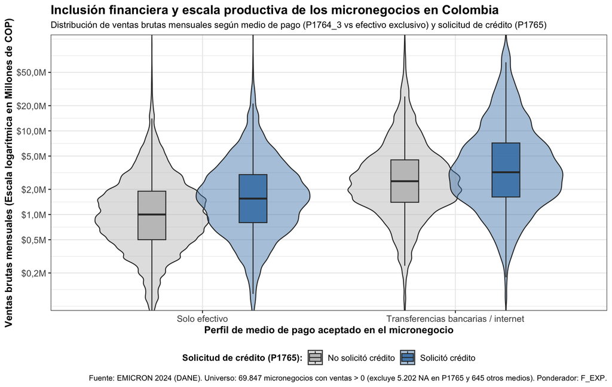

```r
# Subconjunto analítico de los 4 perfiles válidos
datos_micros <- datos_micros_todos %>%
  filter(
    ADOPCION_DIGITAL %in% c("Solo efectivo", "Transferencias bancarias / internet"),
    ACCESO_CREDITO %in% c("No solicitó crédito", "Solicitó crédito")
  ) %>%
  mutate(
    ADOPCION_DIGITAL = factor(ADOPCION_DIGITAL, levels = c("Solo efectivo", "Transferencias bancarias / internet")),
    ACCESO_CREDITO   = factor(ACCESO_CREDITO, levels = c("No solicitó crédito", "Solicitó crédito"))
  )

resumen_micros <- datos_micros %>%
  group_by(ADOPCION_DIGITAL, ACCESO_CREDITO) %>%
  summarise(
    N_MUESTRA      = n(),
    TOTAL_MICROS   = round(sum(F_EXP), 0),
    VENTAS_MEDIANA = round(median(VENTAS_MES_ANTERIOR, na.rm = TRUE), 0),
    .groups        = "drop"
  )
write.csv(resumen_micros, file.path(ruta_outputs, "4_2_tabla_inclusion_ventas.csv"), row.names = FALSE)

# Datos y ponderador: 69.847 micronegocios con ventas positivas y respuesta válida en medios de pago y solicitud
# de crédito (4.711.543 micronegocios expandidos con F_EXP; se documentan 5.202 registros con NA en P1765 y 645 en otros medios).
# Mapeo estético (aes): eje X = perfil de medio de pago (ADOPCION_DIGITAL), eje Y = ventas en millones (VENTAS_MILLONES),
# relleno (fill) = solicitud de crédito (ACCESO_CREDITO), y peso muestral (weight = F_EXP).
grafico_4_2 <- ggplot(datos_micros, aes(x = ADOPCION_DIGITAL, y = VENTAS_MILLONES, fill = ACCESO_CREDITO)) +
  # Capa de violín ponderada (weight = F_EXP) para visualizar la densidad completa de ventas por perfil
  geom_violin(aes(weight = F_EXP), quantiles = NULL, position = position_dodge(0.8), trim = TRUE, alpha = 0.45, scale = "width") +
  # Capa de diagrama de caja ponderada (geom_boxplot) superpuesta para destacar mediana y rango intercuartílico
  geom_boxplot(aes(weight = F_EXP), position = position_dodge(0.8), width = 0.22, outlier.shape = NA, alpha = 0.9) +
  # Escala logarítmica en base 10 sobre el eje Y para corregir la asimetría positiva extrema de las ventas
  scale_y_log10(breaks = c(0.2, 0.5, 1.0, 2.0, 5.0, 10.0, 20.0, 50.0), labels = paste0("$", c("0,2", "0,5", "1,0", "2,0", "5,0", "10,0", "20,0", "50,0"), "M")) +
  # Zoom de coordenadas: conserva todos los registros en las estadísticas.
  coord_cartesian(ylim = c(0.1, 100)) +
  # Escala manual de colores: gris claro para quienes no solicitaron crédito y azul acero para quienes sí solicitaron
  scale_fill_manual(values = c("No solicitó crédito" = "grey75", "Solicitó crédito" = "steelblue")) +
  # Títulos, subtítulo, ejes, leyenda y nota metodológica con las exclusiones documentadas
  labs(
    title    = "Inclusión financiera y escala productiva de los micronegocios en Colombia",
    subtitle = "Distribución de ventas brutas mensuales según medio de pago (P1764_3 vs efectivo exclusivo) y solicitud de crédito (P1765)",
    x        = "Perfil de medio de pago aceptado en el micronegocio",
    y        = "Ventas brutas mensuales (Escala logarítmica en Millones de COP)",
    fill     = "Solicitud de crédito (P1765):",
    caption  = "Fuente: EMICRON 2024 (DANE). Universo: 69.847 micronegocios con ventas > 0 (excluye 5.202 NA en P1765 y 645 otros medios). Ponderador: F_EXP."
  ) +
  # Tema blanco y negro con leyenda inferior
  theme_bw() +
  theme(
    plot.title      = element_text(face = "bold", size = 14),
    plot.subtitle   = element_text(size = 10),
    axis.text       = element_text(size = 10),
    axis.title      = element_text(size = 11, face = "bold"),
    legend.position = "bottom",
    legend.title    = element_text(size = 10, face = "bold"),
    legend.text     = element_text(size = 9.5),
    plot.caption    = element_text(size = 8.5)
  )

grafico_4_2
```

**Código R**

```r
# Exportación en alta resolución (300 DPI)
ggsave(file.path(ruta_outputs, "4_2_inclusion_ventas_micro.png"), plot = grafico_4_2, width = 9.5, height = 6, dpi = 300)
```

## 6.3 4.3 Emparejamiento Laboral: Nivel Educativo y Posición Ocupacional

### 6.3.1 Pregunta y uso explícito de las 13 categorías educativas del DANE

Se evalúa la inserción ocupacional de los ocupados en Colombia (`OCI == 1` en GEIH 2024) cruzando las **13 categorías explícitas de nivel educativo (`P3042`: 1 a 13)** con las **9 posiciones ocupacionales oficiales (`P6430`: 1 a 9)** mediante un gráfico de conteos de intersecciones (`geom_count`).

**Código R**

```r
# Auditoría explícita de códigos educativos y posición ocupacional en ocupados 2024
auditoria_educacion_4_3 <- ocupados_2024_analisis %>%
  summarise(
    TOTAL_OCUPADOS_2024  = n(),
    P3042_CONOCIDOS_1_13 = sum(P3042 %in% 1:13, na.rm = TRUE),
    P3042_NO_SABE_99     = sum(P3042 == 99, na.rm = TRUE),
    P3042_NA             = sum(is.na(P3042)),
    P3042_INVALIDOS      = sum(!is.na(P3042) & !(P3042 %in% c(1:13, 99))),
    P6430_VALIDOS_1_9    = sum(P6430 %in% 1:9, na.rm = TRUE),
    P6430_NA             = sum(is.na(P6430))
  )
print(auditoria_educacion_4_3)
```

```
  TOTAL_OCUPADOS_2024 P3042_CONOCIDOS_1_13 P3042_NO_SABE_99 P3042_NA
1              353672               353668                4        0
  P3042_INVALIDOS P6430_VALIDOS_1_9 P6430_NA
1               0            353672        0
```

**Código R**

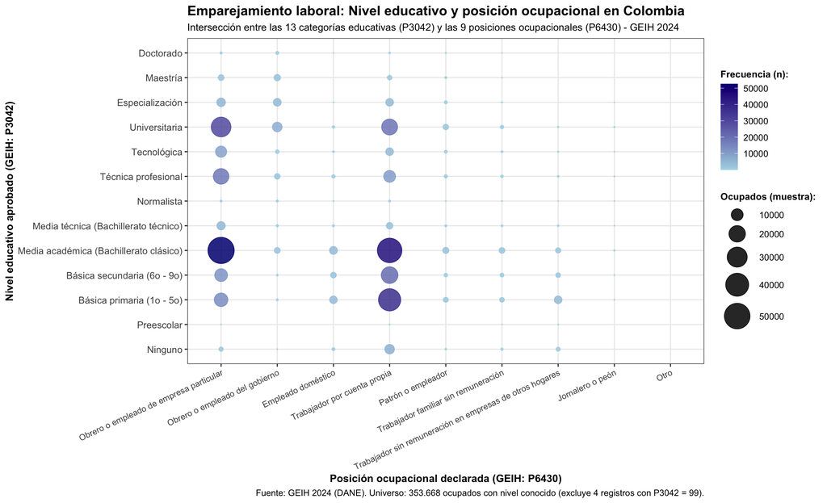

```r
niveles_posicion_p6430 <- etiquetas_posicion$POSICION_OCUPACIONAL

datos_mismatch <- ocupados_2024_analisis %>%
  mutate(
    NIVEL = case_when(
      P3042 == 1  ~ "Ninguno",
      P3042 == 2  ~ "Preescolar",
      P3042 == 3  ~ "Básica primaria (1o - 5o)",
      P3042 == 4  ~ "Básica secundaria (6o - 9o)",
      P3042 == 5  ~ "Media académica (Bachillerato clásico)",
      P3042 == 6  ~ "Media técnica (Bachillerato técnico)",
      P3042 == 7  ~ "Normalista",
      P3042 == 8  ~ "Técnica profesional",
      P3042 == 9  ~ "Tecnológica",
      P3042 == 10 ~ "Universitaria",
      P3042 == 11 ~ "Especialización",
      P3042 == 12 ~ "Maestría",
      P3042 == 13 ~ "Doctorado",
      P3042 == 99 ~ "No sabe, no informa",
      is.na(P3042) ~ "Faltante (NA)",
      TRUE ~ "Código inválido"
    ),
    POSICION = case_when(
      P6430 == 1 ~ "Obrero o empleado de empresa particular",
      P6430 == 2 ~ "Obrero o empleado del gobierno",
      P6430 == 3 ~ "Empleado doméstico",
      P6430 == 4 ~ "Trabajador por cuenta propia",
      P6430 == 5 ~ "Patrón o empleador",
      P6430 == 6 ~ "Trabajador familiar sin remuneración",
      P6430 == 7 ~ "Trabajador sin remuneración en empresas de otros hogares",
      P6430 == 8 ~ "Jornalero o peón",
      P6430 == 9 ~ "Otro",
      TRUE ~ "No informa"
    )
  ) %>%
  # Excluimos los 4 registros con P3042 == 99 ("No sabe, no informa") para analizar los 13 niveles educativos conocidos
  filter(P3042 %in% 1:13, P6430 %in% 1:9) %>%
  mutate(
    NIVEL    = factor(NIVEL, levels = niveles_dane_p3042),
    POSICION = factor(POSICION, levels = niveles_posicion_p6430)
  )

tabla_mismatch <- datos_mismatch %>%
  group_by(NIVEL, POSICION) %>%
  summarise(
    N_MUESTRA              = n(),
    OCUPADOS_SIN_REDONDEAR = sum(FEX_C18 / 12, na.rm = TRUE),
    .groups                = "drop"
  ) %>%
  complete(
    NIVEL,
    POSICION,
    fill = list(N_MUESTRA = 0L, OCUPADOS_SIN_REDONDEAR = 0)
  ) %>%
  group_by(NIVEL) %>%
  mutate(
    PORCENTAJE_FILA = round(OCUPADOS_SIN_REDONDEAR / sum(OCUPADOS_SIN_REDONDEAR) * 100, 1),
    OCUPADOS_EXP    = round(OCUPADOS_SIN_REDONDEAR, 0)
  ) %>%
  ungroup() %>%
  select(NIVEL, POSICION, N_MUESTRA, OCUPADOS_EXP, PORCENTAJE_FILA)

write.csv(tabla_mismatch, file.path(ruta_outputs, "4_3_tabla_mismatch_educacion.csv"), row.names = FALSE)

# Datos y ponderador: 353.668 ocupados de la GEIH 2024 con nivel educativo conocido (1:13) y posición ocupacional (1:9),
# excluyendo 4 registros con P3042 == 99. El conteo muestral se representa mediante geom_count y la tabla exporta FEX_C18 / 12.
# Mapeo estético (aes): eje X = posición ocupacional (POSICION, 9 categorías DANE) y eje Y = nivel educativo (NIVEL, 13 categorías DANE)
# para garantizar la lectura horizontal completa de las 13 etiquetas educativas en el eje vertical.
grafico_4_3 <- ggplot(datos_mismatch, aes(x = POSICION, y = NIVEL)) +
  # Capa de conteo de intersecciones discretas (geom_count): área y color proporcionales a la frecuencia muestral after_stat(n)
  geom_count(aes(color = after_stat(n)), alpha = 0.85) +
  # Escalas discretas en X e Y conservando la totalidad de categorías oficiales del DANE (drop = FALSE)
  scale_x_discrete(drop = FALSE) +
  scale_y_discrete(drop = FALSE) +
  # Escala de área proporcional (cero corresponde a área cero) con diámetro máximo de 12 mm
  scale_size_area(max_size = 12) +
  # Gradiente continuo de color desde azul claro hasta azul marino profundo para reforzar la densidad de la celda
  scale_color_gradient(low = "lightblue", high = "navy") +
  # Etiquetas descriptivas de ambos ejes categóricos oficiales del DANE y nota metodológica
  labs(
    title    = "Emparejamiento laboral: Nivel educativo y posición ocupacional en Colombia",
    subtitle = "Intersección entre las 13 categorías educativas (P3042) y las 9 posiciones ocupacionales (P6430) - GEIH 2024",
    x        = "Posición ocupacional declarada (GEIH: P6430)",
    y        = "Nivel educativo aprobado (GEIH: P3042)",
    size     = "Ocupados (muestra):",
    color    = "Frecuencia (n):",
    caption  = "Fuente: GEIH 2024 (DANE). Universo: 353.668 ocupados con nivel conocido (excluye 4 registros con P3042 = 99)."
  ) +
  # Tema blanco y negro con etiquetas del eje X inclinadas 25 grados para evitar solapamiento entre las 9 posiciones
  theme_bw() +
  theme(
    plot.title      = element_text(face = "bold", size = 13.5),
    plot.subtitle   = element_text(size = 10),
    axis.text.x     = element_text(size = 8.5, angle = 25, hjust = 1),
    axis.text.y     = element_text(size = 9.5),
    axis.title      = element_text(size = 10.5, face = "bold"),
    legend.position = "right",
    legend.title    = element_text(size = 9.5, face = "bold"),
    legend.text     = element_text(size = 9)
  )

grafico_4_3
```

**Código R**

```r
# Exportación en alta resolución (300 DPI, 11.5 x 7 pulgadas para acomodar la matriz 13 x 9)
ggsave(file.path(ruta_outputs, "4_3_mismatch_educacion.png"), plot = grafico_4_3, width = 11.5, height = 7, dpi = 300)
```

**Interpretación:** El cruce comprende 353.668 ocupados con educación conocida; excluye cuatro registros con `P3042 == 99` (473 ocupados expandidos), sin faltantes ni códigos inválidos (`4_3_tabla_mismatch_educacion.csv`). El gráfico representa frecuencias muestrales; los porcentajes y poblaciones siguientes usan `FEX_C18 / 12`. Cuenta propia predomina en *Ninguno* (62,5 %), *Primaria* (54,8 %) y *Secundaria* (48,6 %). Desde *Media académica* (47,8 % empleado particular; 39,9 % cuenta propia) y *Media técnica* (57,8 %; 32,7 %) predomina el empleo particular. Sus proporciones son 61,5 % en técnica profesional, 66,6 % en tecnológica, 62,1 % en universitaria, 58,4 % en especialización, 55,6 % en maestría y 56,5 % en doctorado. El empleo público pasa de 10,8 % en universitaria a 28,2 % en doctorado. Hay 986.256 ocupados con educación superior por cuenta propia, incluidos 454.991 universitarios y 360.875 técnicos profesionales. Identificar sobreeducación requiere conocer la educación exigida por el puesto (Hartog, 2000).

# 7 Checklist de Calidad Pedagógica y Reproducibilidad

En concordancia con la sección 13 de la *Guía pedagógica para escribir código y documentación en R*, se documenta el cumplimiento de las buenas prácticas aplicadas:

| Criterio Pedagógico | Estado | Justificación en el Cuaderno |
| --- | --- | --- |
| **Lectura humana en 3 capas** | Cumplido | Cada numeral cuenta con introducción previa (contexto/regla), código limpio comentado e interpretación posterior explícita. |
| **Convenciones de estilo R** | Cumplido | Nombres consistentes en `snake_case`, asignación unificada con `<-`, llamadas divididas por argumentos legibles. |
| **Reproducibilidad en sesión limpia** | Cumplido | Rutas centralizadas con `{here}`, sin rutas absolutas ni `setwd()`. Parámetros y directorios verificados al inicio. |
| **Control de llaves y joins** | Cumplido | Auditoría de unicidad en 4 módulos GEIH y 4 módulos EMICRON. Control con `stop()` para evitar multiplicación de filas. |
| **Ponderadores estadísticos** | Cumplido | Uso estricto de `FEX_C18 / 3` para trimestres, `FEX_C18 / 12` para anuales GEIH, y `F_EXP` para universo micronegocios. |
| **Rigor interpretativo** | Cumplido | Se distingue explícitamente descripción/asociación de causalidad, explicitando factores de confusión en el punto 3.3. |
| **Persistencia de artefactos** | Cumplido | Se reexportan y auditan las 33 salidas a la carpeta `outputs/` de la raíz del proyecto. |

# 8 Información de Sesión

**Código R**